# Predicting Patient Survival in Critical Illnesses

[figure not shown]

Faculty of Economic Sciences

University of Warsaw

MA in Data Science and Business Analytics

# Predicting Patient Survival in Critical Illnesses

Machine Learning 2 Classification

Karolina Solarska, Zuzanna Kostecka

2024-02-06 01:50:09.653643

```r
# ############################################################################
#           University of Warsaw, Faculty of Economic Sciences               #
#                                                                            #
#             Karolina Solarska, Zuzanna Kostecka                            #
#                        Machine Learning 2                                  #
#                          Classification                                    #
#                                                                            #
# ############################################################################
```

## Project Scope:

The main objective of this project is to develop a classification model that identify the factors that contribute to in-hospital mortality and predict the likelihood of this outcome for patients.

Dependent Variable: The dependent variable for the project is hospdead, a binary indicator representing whether a patient died in the hospital during their stay.

## 1. Understanding and Describing the Data

First we loaded all necessary packages.

```r
packages <- c("fastDummies", "dplyr", "tidyr", "caret", "ggplot2", "DescTools",
              "corrplot", "rpart", "tidyverse", "MASS", "tree", "rpart.plot",
              "rattle", "pROC", "e1071", "randomForest", "ranger",
              "xgboost", "here")

new_packages <- packages[!(packages %in% installed.packages()[,"Package"])]
if(length(new_packages)) install.packages(new_packages)

lapply(packages, library, character.only = TRUE)
```

[output not shown]

[output cut: 111 more lines]

```r
source(here("data", "getAccuracyAndGini.R"))
```

Initial exploration of dataset.

```r
# setwd("C:/Users/karla/Desktop/Machine Learning 2/Projekt/Classification")
# Load the dataset
# data <- read.csv("data/c4.csv")

data <- read.csv(here("data", "c4.csv"))

# Check the structure of the dataset
head(data)
```

```
##   id adlp adls    adlsc      age      alb aps  avtisst      bili bun         ca
## 1  1   NA    5 5.000000 43.25000 3.199707  66 53.33331 1.5998535  81         no
## 2  2    1    0 0.000000 61.26999       NA  26 18.00000        NA  NA metastatic
## 3  3    3    0 0.000000 59.49298 2.199707  13 14.00000 5.1992188  92         no
## 4  4   NA   NA 2.162598 64.07397       NA  60 40.50000 0.5000000  41         no
## 5  5   NA    2 2.000000 68.28198 2.799805  51 35.00000 1.6999512  49         no
## 6  6    0    0 0.000000 46.72998       NA  11 10.00000 0.8999023  NA metastatic
##      charges      crea death dementia diabetes            dnr dnrday
## 1 133810.000 2.8999023     1        0        0 dnr after sadm     12
## 2   3754.000 0.7999268     1        0        0         no dnr      6
## 3   5043.000 8.3984375     0        0        0         no dnr      5
## 4 280170.000 5.1992188     1        0        0 dnr after sadm      7
## 5  22189.000 1.5000000     1        0        1         no dnr     10
## 6   6932.848 1.0998535     1        0        0         no dnr      6
##              dzclass           dzgroup edu    feat01    feat02    feat03
```

[output cut: 34 more lines]

```r
str(data)
```

```
## 'data.frame':    10105 obs. of  56 variables:
##  $ id      : int  1 2 3 4 5 6 7 8 9 10 ...
##  $ adlp    : int  NA 1 3 NA NA 0 NA NA 0 NA ...
##  $ adls    : int  5 0 0 NA 2 0 2 1 0 0 ...
##  $ adlsc   : num  5 0 0 2.16 2 ...
##  $ age     : num  43.2 61.3 59.5 64.1 68.3 ...
##  $ alb     : num  3.2 NA 2.2 NA 2.8 ...
##  $ aps     : int  66 26 13 60 51 11 54 35 62 77 ...
##  $ avtisst : num  53.3 18 14 40.5 35 ...
##  $ bili    : num  1.6 NA 5.2 0.5 1.7 ...
##  $ bun     : num  81 NA 92 41 49 NA 53 13 67 90 ...
##  $ ca      : chr  "no" "metastatic" "no" "no" ...
##  $ charges : num  133810 3754 5043 280170 22189 ...
##  $ crea    : num  2.9 0.8 8.4 5.2 1.5 ...
##  $ death   : int  1 1 0 1 1 1 1 0 0 1 ...
```

[output cut: 42 more lines]

```r
dim(data)
```

```
## [1] 10105    56
```

```r
summary(data)
```

```
##        id             adlp            adls           adlsc
##  Min.   :    1   Min.   :0.000   Min.   :0.000   Min.   :0.000
##  1st Qu.: 2527   1st Qu.:0.000   1st Qu.:0.000   1st Qu.:0.000
##  Median : 5053   Median :0.000   Median :1.000   Median :1.000
##  Mean   : 5053   Mean   :1.156   Mean   :1.643   Mean   :1.895
##  3rd Qu.: 7579   3rd Qu.:2.000   3rd Qu.:3.000   3rd Qu.:3.000
##  Max.   :10105   Max.   :7.000   Max.   :7.000   Max.   :7.073
##                  NA's   :6239    NA's   :3183
##       age              alb              aps           avtisst
##  Min.   : 18.04   Min.   : 0.400   Min.   :  0.0   Min.   : 1.00
##  1st Qu.: 52.73   1st Qu.: 2.400   1st Qu.: 23.0   1st Qu.:12.00
##  Median : 64.85   Median : 2.900   Median : 34.0   Median :19.50
##  Mean   : 62.64   Mean   : 2.955   Mean   : 37.6   Mean   :22.58
##  3rd Qu.: 74.06   3rd Qu.: 3.600   3rd Qu.: 49.0   3rd Qu.:31.50
##  Max.   :101.85   Max.   :29.000   Max.   :143.0   Max.   :83.00
##                   NA's   :3757     NA's   :1       NA's   :91
##       bili              bun              ca               charges
##  Min.   : 0.1000   Min.   :  1.00   Length:10105       Min.   :   1169
##  1st Qu.: 0.5000   1st Qu.: 14.00   Class :character   1st Qu.:   9701
##  Median : 0.8999   Median : 23.00   Mode  :character   Median :  24806
##  Mean   : 2.5312   Mean   : 32.08                      Mean   :  59195
##  3rd Qu.: 1.8999   3rd Qu.: 42.00                      3rd Qu.:  63757
##  Max.   :63.0000   Max.   :300.00                      Max.   :1435423
##  NA's   :2878      NA's   :4836                        NA's   :198
##       crea              death           dementia          diabetes
##  Min.   : 0.09999   Min.   :0.0000   Min.   :0.00000   Min.   :0.0000
##  1st Qu.: 0.89990   1st Qu.:0.0000   1st Qu.:0.00000   1st Qu.:0.0000
##  Median : 1.19995   Median :1.0000   Median :0.00000   Median :0.0000
##  Mean   : 1.76300   Mean   :0.6795   Mean   :0.03295   Mean   :0.1951
##  3rd Qu.: 1.89990   3rd Qu.:1.0000   3rd Qu.:0.00000   3rd Qu.:0.0000
##  Max.   :21.50000   Max.   :1.0000   Max.   :1.00000   Max.   :1.0000
##  NA's   :73
##      dnr                dnrday         dzclass            dzgroup
##  Length:10105       Min.   :-88.00   Length:10105       Length:10105
##  Class :character   1st Qu.:  4.00   Class :character   Class :character
##  Mode  :character   Median :  9.00   Mode  :character   Mode  :character
##                     Mean   : 14.47
##                     3rd Qu.: 17.00
##                     Max.   :285.00
##                     NA's   :34
```

[output cut: 57 more lines]

```
##  Min.   : 0.20   Min.   :0.0000   Min.   :0.0000   Min.   :31.70
##  1st Qu.:19.00   1st Qu.:0.5070   1st Qu.:0.3409   1st Qu.:36.20
##  Median :23.90   Median :0.7150   Median :0.5724   Median :36.70
##  Mean   :25.55   Mean   :0.6355   Mean   :0.5195   Mean   :37.10
##  3rd Qu.:30.20   3rd Qu.:0.8259   3rd Qu.:0.7260   3rd Qu.:38.09
##  Max.   :99.19   Max.   :0.9700   Max.   :0.9480   Max.   :41.70
##  NA's   :1       NA's   :1        NA's   :1        NA's   :1
##      totcst          totmcst             urine           wblc
##  Min.   :     0   Min.   :  -102.7   Min.   :   0   Min.   :  0.000
##  1st Qu.:  5907   1st Qu.:  5178.4   1st Qu.:1175   1st Qu.:  6.899
##  Median : 14306   Median : 13103.4   Median :1975   Median : 10.600
##  Mean   : 30508   Mean   : 28606.4   Mean   :2202   Mean   : 12.335
##  3rd Qu.: 35654   3rd Qu.: 33651.0   3rd Qu.:2990   3rd Qu.: 15.299
##  Max.   :633212   Max.   :710682.0   Max.   :9000   Max.   :200.000
##  NA's   :994      NA's   :3864       NA's   :5405   NA's   :234
```

```r
# View(data)
```

### 1.1 Dataset Description

The dataset, ‘c4.csv’, contains comprehensive medical records of 10,105 critically ill patients admitted to five medical centers in the United States between 1989-1991 and 1992-1994. The patients are categorized into nine critical illness groups:

Acute Respiratory Failure (ARF) Chronic Obstructive Pulmonary Disease (COPD) Congestive Heart Failure (CHF) Liver Disease Coma Colon Cancer Lung Cancer Multiple Organ System Failure with Malignancy (MOSF w/Malignancy) Multiple Organ System Failure with Sepsis (MOSF w/Sepsis)

The dataset encompasses 56 variables that include demographic information (age, sex, race, income), clinical measurements (e.g., blood pressure, glucose levels, white blood cell count), and details about the severity and type of disease. This rich dataset offers a comprehensive view of the factors that might influence patient outcomes in a hospital setting.

This project aims to leverage advanced machine learning techniques to analyze various factors influencing in-hospital mortality. The insights gleaned from this analysis can significantly aid healthcare providers in identifying high-risk patients, improving patient care, and managing hospital resources more effectively. Furthermore, the findings of this project could contribute to the broader field of healthcare analytics, supporting the movement towards data-driven decision-making in medicine. By accurately predicting in-hospital mortality, this project can help in devising strategies to improve patient outcomes and potentially save lives.

### 1.2 Feature Selection

```r
# List of features to check for missing values
missing_values <- colSums(is.na(data))
print(missing_values)
```

```
##       id     adlp     adls    adlsc      age      alb      aps  avtisst
##        0     6239     3183        0        0     3757        1       91
##     bili      bun       ca  charges     crea    death dementia diabetes
##     2878     4836        0      198       73        0        0        0
##      dnr   dnrday  dzclass  dzgroup      edu   feat01   feat02   feat03
##       34       34        0        0     1821        0        0        0
##   feat04   feat05   feat06   feat07   feat08   feat09   feat10  glucose
##        0        0        0        0        0        0        0     5001
##     hday hospdead      hrt   income   meanbp   num.co     pafi       ph
##        0        0        1     3311        1        0     2589     2547
##    prg2m    prg6m     race     resp    scoma      sex    sfdm2      sod
##     1864     1846       49        1        1        0     1539        1
##      sps   surv2m   surv6m     temp   totcst  totmcst    urine     wblc
##        1        1        1        1      994     3864     5405      234
```

```r
features_to_check <- c("alb", "avtisst", "bili", "bun", "charges", "crea",
                       "dnr", "dnrday", "edu", "glucose", "hrt", "income",
                       "meanbp", "pafi", "ph", "prg2m", "prg6m", "race",
                       "resp", "sfdm2", "sod", "temp", "totcst", "totmcst",
                       "urine", "wblc")

missing_values <- sapply(data[features_to_check], function(x) sum(is.na(x)))
missing_percentage <- sapply(data[features_to_check], function(x) mean(is.na(x)) * 100)
missing_data_summary <- data.frame(Feature = features_to_check,
                                   MissingValues = missing_values,
                                   MissingPercentage = missing_percentage)
print(missing_data_summary)
```

```
##         Feature MissingValues MissingPercentage
## alb         alb          3757      37.179614052
## avtisst avtisst            91       0.900544285
## bili       bili          2878      28.480950025
## bun         bun          4836      47.857496289
## charges charges           198       1.959426027
## crea       crea            73       0.722414646
## dnr         dnr            34       0.336467095
## dnrday   dnrday            34       0.336467095
## edu         edu          1821      18.020781791
## glucose glucose          5001      49.490351311
## hrt         hrt             1       0.009896091
## income   income          3311      32.765957447
## meanbp   meanbp             1       0.009896091
## pafi       pafi          2589      25.620979713
## ph           ph          2547      25.205343889
## prg2m     prg2m          1864      18.446313706
## prg6m     prg6m          1846      18.268184067
## race       race            49       0.484908461
## resp       resp             1       0.009896091
## sfdm2     sfdm2          1539      15.230084117
## sod         sod             1       0.009896091
## temp       temp             1       0.009896091
## totcst   totcst           994       9.836714498
## totmcst totmcst          3864      38.238495794
## urine     urine          5405      53.488372093
## wblc       wblc           234       2.315685304
```

```r
# removal of unnecessary variables
data <- subset(data, select = -c(id, adlp, adls, alb, aps, bili, bun, death,
                                 dzclass, glucose, income, pafi, ph, scoma,
                                 sps, surv2m, surv6m, totcst, totmcst, urine))

## surv2m, surv6m: features predicted by other models.
## sps, aps, scoma: model-predicted scores
## d.time: our focus is solely on in-hospital mortality.
# adlp, adls: correlated with sfdm2 (as said in data desciption)
## death: focus on in-hospital mortality
## dzclass: dzgroup is more specific variable
## totcst, totmcst: charges is similar and has less missings
## income, pafi, alb, bili, ph, glucose, bun, urine: very high missing data
```

### 1.3 Data Preprocessing

Target Variable 0 - represent patients who did not die in the hospital. 1 - represent patients who did die in the hospital.

```r
# hospdead
str(data$hospdead)
```

```
##  int [1:10105] 1 0 0 1 0 0 0 0 0 1 ...
```

```r
sum(is.na(data$hospdead))
```

```
## [1] 0
```

```r
unique(data$hospdead)
```

```
## [1] 1 0
```

```r
# checking the distribution of hospdead
summary(data$hospdead)
```

```
##    Min. 1st Qu.  Median    Mean 3rd Qu.    Max.
##  0.0000  0.0000  0.0000  0.2587  1.0000  1.0000
```

```r
table(data$hospdead)
```

```
##
##    0    1
## 7491 2614
```

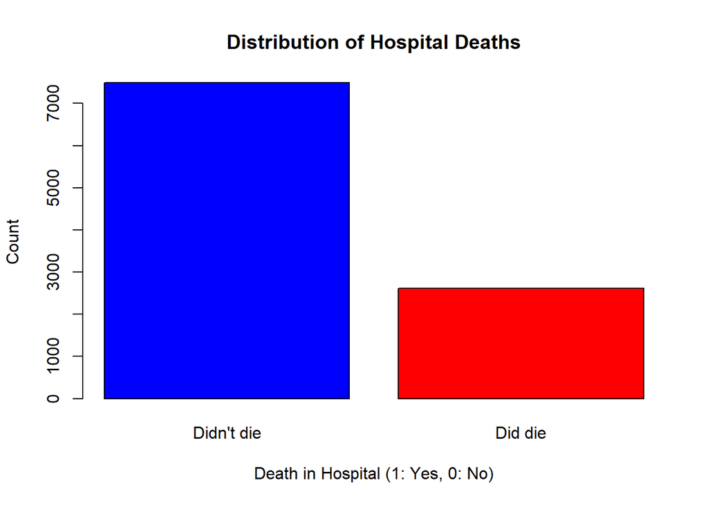

```r
barplot(table(data$hospdead), main = "Distribution of Hospital Deaths",
        xlab = "Death in Hospital (1: Yes, 0: No)",
        ylab = "Count",
        col = c("blue", "red"),
        names.arg = c("Didn't die", "Did die"))
```

```r
features_to_check2 <- c("avtisst", "ca", "charges", "crea", "dnr", "dzgroup",
                        "edu", "hrt", "meanbp", "num.co", "prg2m", "prg6m",
                        "race", "sfdm2", "sex", "temp", "wblc", "feat01",
                        "feat02", "feat03", "feat04", "feat05", "feat06",
                        "feat07", "feat08", "feat09", "feat10")

for (feature in features_to_check2) {
  cat("Feature:", feature, "\n")
  cat("Class:", class(data[[feature]]), "\n")
  cat("Number of NA values:", sum(is.na(data[[feature]])), "\n\n")
}
```

```
## Feature: avtisst
## Class: numeric
## Number of NA values: 91
##
## Feature: ca
## Class: character
## Number of NA values: 0
##
## Feature: charges
## Class: numeric
## Number of NA values: 198
##
## Feature: crea
## Class: numeric
## Number of NA values: 73
##
## Feature: dnr
## Class: character
## Number of NA values: 34
##
## Feature: dzgroup
## Class: character
## Number of NA values: 0
##
## Feature: edu
## Class: integer
## Number of NA values: 1821
##
## Feature: hrt
## Class: numeric
## Number of NA values: 1
##
## Feature: meanbp
## Class: numeric
## Number of NA values: 1
##
## Feature: num.co
## Class: integer
## Number of NA values: 0
##
```

[output cut: 52 more lines]

```
## Feature: feat07
## Class: numeric
## Number of NA values: 0
##
## Feature: feat08
## Class: numeric
## Number of NA values: 0
##
## Feature: feat09
## Class: numeric
## Number of NA values: 0
##
## Feature: feat10
## Class: numeric
## Number of NA values: 0
```

```r
# changing types of features
data$ca <- ifelse(data$ca == "yes", 1, 0)
data$ca <- as.integer(data$ca)
data$dnr <- ifelse(data$dnr == "no dnr", 1, ifelse(data$dnr %in% c("dnr after sadm", "dnr before sadm"), 0, NA))
data$dnr <- as.integer(data$dnr)
data$dementia <- as.integer(data$dementia)
data$diabetes <- as.integer(data$diabetes)
data$hrt <- as.integer(data$hrt)
data$meanbp <- as.integer(data$meanbp)
data$sex <- ifelse(data$sex == "male", 0, 1)
data$sex <- as.integer(data$sex)
data$sfdm2 <- as.integer(factor(data$sfdm2,
                                   levels = c("no(M2 and SIP pres)",
                                              "adl>=4 (>=5 if sur)",
                                              "SIP>=30",
                                              "Coma or Intub",
                                              "<2 mo. follow-up"),
                                   labels = c(1, 2, 3, 4, 5)))

# handle with missing values
data <- data[!is.na(data$dnr), ]
data <- data[!is.na(data$hrt), ]
data <- data[!is.na(data$meanbp), ]
data <- data[!is.na(data$race), ]
data <- data[!is.na(data$temp), ]
data$avtisst[is.na(data$avtisst)] <- mean(data$avtisst, na.rm = TRUE)
data$charges[is.na(data$charges)] <- mean(data$charges, na.rm = TRUE)
data$crea[is.na(data$crea)] <- mean(data$crea, na.rm = TRUE)
data$edu[is.na(data$edu)] <- Mode(data$edu[!is.na(data$edu)])
data$prg2m[is.na(data$prg2m)] <- mean(data$prg2m, na.rm = TRUE)
data$prg6m[is.na(data$prg6m)] <- mean(data$prg6m, na.rm = TRUE)
data$sfdm2[is.na(data$sfdm2)] <- Mode(data$sfdm2[!is.na(data$sfdm2)])
data$wblc[is.na(data$wblc)] <- mean(data$wblc, na.rm = TRUE)


# changing as dummy variable
data <- fastDummies::dummy_cols(
  data,
  select_columns = c("dzgroup", "race"),
  remove_selected_columns = TRUE,
)

# changing column names
data <- data %>%
    rename(arf_w_sepsis = "dzgroup_ARF/MOSF w/Sepsis",
           chp = "dzgroup_CHF",
           cirrhosis = "dzgroup_Cirrhosis",
           colon_cancer = "dzgroup_Colon Cancer",
           coma = "dzgroup_Coma",
           copd = "dzgroup_COPD",
           lung_cancer = "dzgroup_Lung Cancer",
           mosf_w_malig = "dzgroup_MOSF w/Malig",
           )

# removal of unnecessary variables
data <- subset(data, select = -c(race_asian, race_black, race_hispanic,
                                 race_other))
```

```r
# Check of missing values and data types after changes
missing_values2 <- colSums(is.na(data))
print(missing_values2)
```

```
##        adlsc          age      avtisst           ca      charges         crea
##            0            0            0            0            0            0
##     dementia     diabetes          dnr       dnrday          edu       feat01
##            0            0            0            0            0            0
##       feat02       feat03       feat04       feat05       feat06       feat07
##            0            0            0            0            0            0
##       feat08       feat09       feat10         hday     hospdead          hrt
##            0            0            0            0            0            0
##       meanbp       num.co        prg2m        prg6m         resp          sex
##            0            0            0            0            0            0
##        sfdm2          sod         temp         wblc arf_w_sepsis          chp
##            0            0            0            0            0            0
##    cirrhosis colon_cancer         coma         copd  lung_cancer mosf_w_malig
##            0            0            0            0            0            0
##   race_white
##            0
```

```r
str(data)
```

```
## 'data.frame':    10021 obs. of  43 variables:
##  $ adlsc       : num  5 0 0 2.16 2 ...
##  $ age         : num  43.2 61.3 59.5 64.1 68.3 ...
##  $ avtisst     : num  53.3 18 14 40.5 35 ...
##  $ ca          : int  0 0 0 0 0 0 0 0 0 0 ...
##  $ charges     : num  133810 3754 5043 280170 22189 ...
##  $ crea        : num  2.9 0.8 8.4 5.2 1.5 ...
##  $ dementia    : int  0 0 0 0 0 0 0 0 0 0 ...
##  $ diabetes    : int  0 0 0 0 1 0 0 1 0 0 ...
##  $ dnr         : int  0 1 1 0 1 1 1 1 1 0 ...
##  $ dnrday      : int  12 6 5 7 10 6 32 21 14 11 ...
##  $ edu         : int  8 10 7 12 12 12 11 14 11 8 ...
##  $ feat01      : num  1.541 0.849 1.642 1.099 0.653 ...
##  $ feat02      : num  0.558 0.572 0.514 0.683 0.67 ...
##  $ feat03      : num  0.667 0.626 0.409 0.617 0.628 ...
```

[output cut: 29 more lines]

### 1.4 Explanatory data analysis

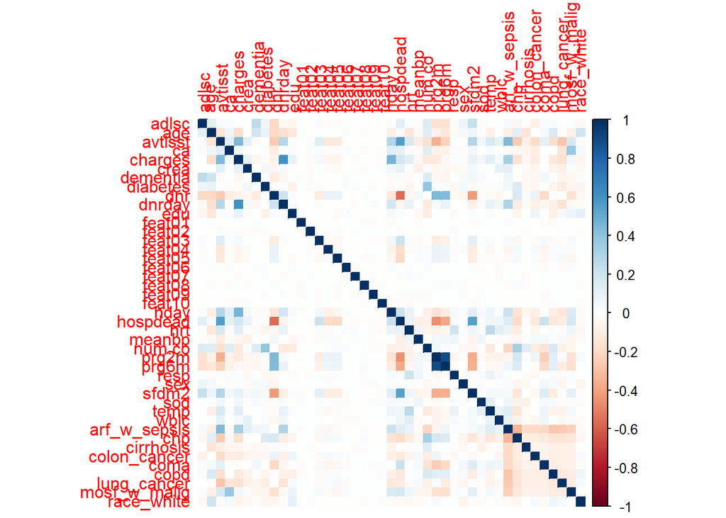

```r
# Correlation Heatmap
corrplot(cor(data[, sapply(data, is.numeric)]), method = "color")
```

```r
# Compute the correlation matrix
correlation_matrix <- cor(data)
print(correlation_matrix)
```

```
##                      adlsc           age       avtisst           ca
## adlsc         1.0000000000  0.1164568389  0.0294768847  0.020549068
## age           0.1164568389  1.0000000000 -0.1353761913  0.064457891
## avtisst       0.0294768847 -0.1353761913  1.0000000000  0.119447209
## ca            0.0205490675  0.0644578909  0.1194472091  1.000000000
## charges       0.0079585656 -0.1702097158  0.4464520936  0.055470563
## crea         -0.0073450640 -0.0034449128  0.1143994329  0.013517663
## dementia      0.2515206355  0.1995638617 -0.0279271168  0.001520666
## diabetes      0.0610434871  0.0951804201  0.0048046119 -0.018913434
## dnr          -0.2044222640 -0.2036383183 -0.2558578684 -0.103456009
## dnrday       -0.0306569826 -0.1603677699  0.2886005262 -0.008433122
## edu          -0.0597085881 -0.1202978927  0.0205845290  0.022610601
## feat01        0.0070330621  0.0162547689 -0.0051837061  0.004274676
## feat02       -0.0017192575 -0.0001713811  0.0101227123  0.013162658
## feat03        0.0273791434  0.0078122363  0.1318212344  0.026174997
## feat04       -0.0104914659 -0.0095749958 -0.1259720221 -0.019780869
## feat05       -0.0133960924  0.0022669999 -0.1143664661 -0.017071519
## feat06       -0.0007289377  0.0102884972 -0.0073393498  0.018069935
## feat07        0.0088690706 -0.0034924176 -0.0021608490  0.005993405
## feat08       -0.0002942681 -0.0129672678  0.0022559346 -0.018208079
## feat09       -0.0016918072  0.0066419102 -0.0058154271  0.001035499
## feat10       -0.0016953973  0.0023144744 -0.0081822852 -0.016521231
## hday          0.0137642366 -0.0808342827  0.2974584480  0.129893587
## hospdead      0.1286496752  0.0375434652  0.5501420995  0.107836935
## hrt           0.0184575853 -0.1242270513  0.1676269511  0.026312039
## meanbp       -0.0161012475 -0.0335959080 -0.1016632539 -0.026296507
## num.co        0.1428545631  0.1300060467 -0.1608598525  0.139199035
## prg2m        -0.1541494752 -0.0769928828 -0.3535681696 -0.078603144
## prg6m        -0.1580163544 -0.1206557320 -0.2249858168 -0.072531934
## resp          0.0185676261 -0.0210428495  0.0170141214  0.029494702
## sex           0.0782221590  0.0426641875 -0.0003725996 -0.015129382
## sfdm2         0.2393475540  0.0603253014  0.2966485911  0.059572132
## sod           0.0189858164  0.0180035170  0.0587003560 -0.002333079
## temp         -0.0006081162 -0.0856210325  0.1670622663  0.029791666
## wblc          0.0077936459  0.0010681580  0.1078831032 -0.008606553
## arf_w_sepsis  0.0396334284 -0.0826217827  0.4479369795 -0.023333944
## chp          -0.0458168519  0.1142672724 -0.2595334534 -0.040173747
## cirrhosis     0.0026180339 -0.1418894566 -0.0829385138 -0.058957728
## colon_cancer -0.0761852023 -0.0077664396 -0.1858538485 -0.096824193
## coma          0.0204374729  0.0426969682  0.1197809844 -0.005594111
```

[output cut: 429 more lines]

```
## resp          0.0298154857  0.0034048725
## sex           0.0117804475 -0.0512122956
## sfdm2         0.1186381885 -0.0135825850
## sod          -0.0111722723 -0.0174908417
## temp          0.0461227756 -0.0069770076
## wblc         -0.0226393010 -0.0116078333
## arf_w_sepsis -0.2303136123 -0.0275802899
## chp          -0.1241538190 -0.0485067495
## cirrhosis    -0.0713435225 -0.0014193931
## colon_cancer -0.0706033214  0.0338746127
## coma         -0.0768772606 -0.0297746612
## copd         -0.1017970002  0.0653705669
## lung_cancer  -0.0976983595  0.0405604358
## mosf_w_malig  1.0000000000 -0.0063976464
## race_white   -0.0063976464  1.0000000000
```

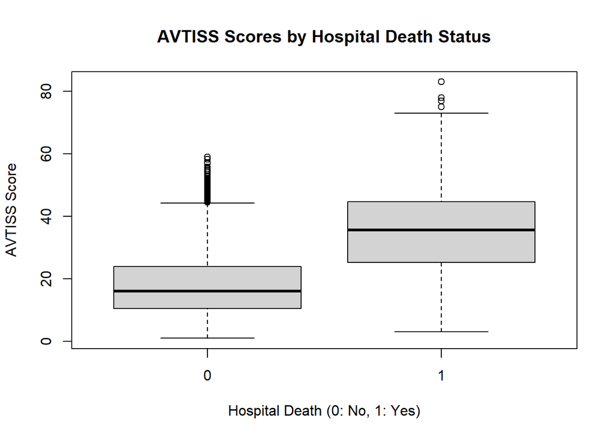

```r
# prg2m and prg6m are highly correlated (0.897), so physicians' 2-month and 6-month survival estimates are closely related. We decide to remove prg2m
data <- subset(data, select = -c(prg2m))

# avtisst and hospdead have a significant positive correlation (0.55), suggesting that higher AVTISS scores might be associated with increased hospital death rates. We will use a box plot to compare the distributions of avtisst scores for patients who died in the hospital versus those who did not.
boxplot(data$avtisst ~ data$hospdead, main = "AVTISS Scores by Hospital Death Status",
        xlab = "Hospital Death (0: No, 1: Yes)", ylab = "AVTISS Score")
```

```r
cor_avtisst_hospdead <- cor.test(data$avtisst, data$hospdead, method = "pearson")
print(cor_avtisst_hospdead)
```

```
##
##  Pearson's product-moment correlation
##
## data:  data$avtisst and data$hospdead
## t = 65.942, df = 10019, p-value < 2.2e-16
## alternative hypothesis: true correlation is not equal to 0
## 95 percent confidence interval:
##  0.5363398 0.5636503
## sample estimates:
##       cor
## 0.5501421
```

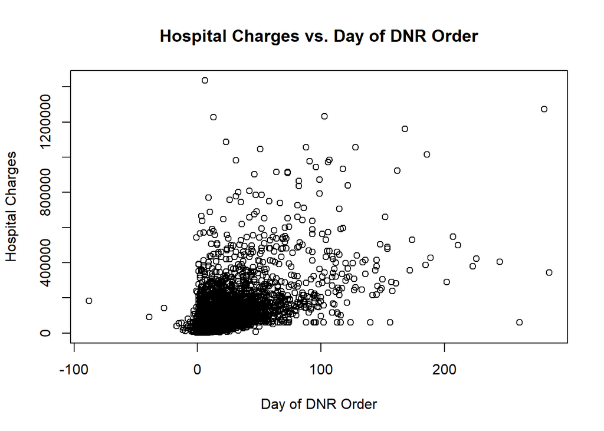

```r
# charges and dnrday are highly correlated (0.602)
plot(data$charges ~ data$dnrday, main = "Hospital Charges vs. Day of DNR Order",
     xlab = "Day of DNR Order", ylab = "Hospital Charges")
```

```r
cor_charges_dnrday <- cor.test(data$charges, data$dnrday, method = "pearson")
print(cor_charges_dnrday)
```

```
##
##  Pearson's product-moment correlation
##
## data:  data$charges and data$dnrday
## t = 75.642, df = 10019, p-value < 2.2e-16
## alternative hypothesis: true correlation is not equal to 0
## 95 percent confidence interval:
##  0.5902944 0.6152228
## sample estimates:
##       cor
## 0.6029058
```

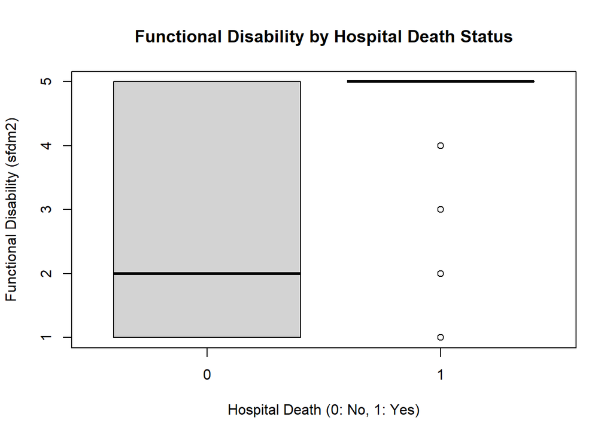

```r
# hospdead and sfdm2 are highly correlated (0.547)
boxplot(data$sfdm2 ~ data$hospdead, main = "Functional Disability by Hospital Death Status",
        xlab = "Hospital Death (0: No, 1: Yes)", ylab = "Functional Disability (sfdm2)")
```

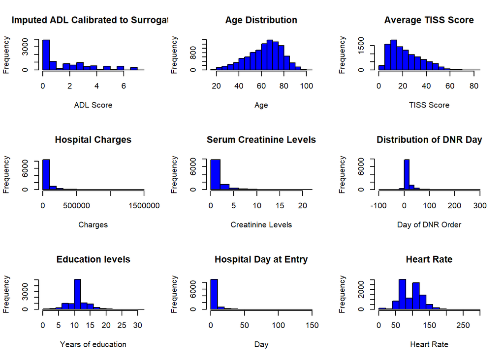

```r
# Checking the distribution

# histograms for continuous variables
par(mfrow = c(3, 3))
hist(data$adlsc, main = "Imputed ADL Calibrated to Surrogate", xlab = "ADL Score", col = "blue")
hist(data$age, main = "Age Distribution", xlab = "Age", col = "blue")
hist(data$avtisst, main = "Average TISS Score", xlab = "TISS Score", col = "blue")
hist(data$charges, main = "Hospital Charges", xlab = "Charges", col = "blue")
hist(data$crea, main = "Serum Creatinine Levels", xlab = "Creatinine Levels", col = "blue")
hist(data$dnrday, main = "Distribution of DNR Day", xlab = "Day of DNR Order", col = "blue")
hist(data$edu, main = "Education levels", xlab = "Years of education", col = "blue")
hist(data$hday, main = "Hospital Day at Entry", xlab = "Day", col = "blue")
hist(data$hrt, main = "Heart Rate", xlab = "Heart Rate", col = "blue")
```

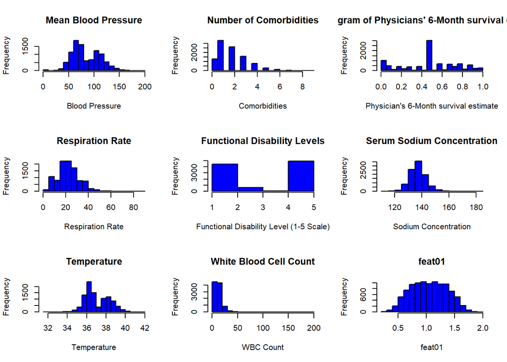

```r
hist(data$meanbp, main = "Mean Blood Pressure", xlab = "Blood Pressure", col = "blue")
hist(data$num.co, main = "Number of Comorbidities", xlab = "Comorbidities", col = "blue")
hist(data$prg6m, main = "Histogram of Physicians' 6-Month survival estimates", xlab = "Physician's 6-Month survival estimate", col = "blue")
hist(data$resp, main = "Respiration Rate", xlab = "Respiration Rate", col = "blue")
hist(data$sfdm2, main = "Functional Disability Levels",
     xlab = "Functional Disability Level (1-5 Scale)", col = "blue",
     breaks = 5)
hist(data$sod, main = "Serum Sodium Concentration", xlab = "Sodium Concentration", col = "blue")
hist(data$temp, main = "Temperature", xlab = "Temperature", col = "blue")
hist(data$wblc, main = "White Blood Cell Count", xlab = "WBC Count", col = "blue")
hist(data$feat01, main = "feat01", xlab = "feat01", col = "blue")
```

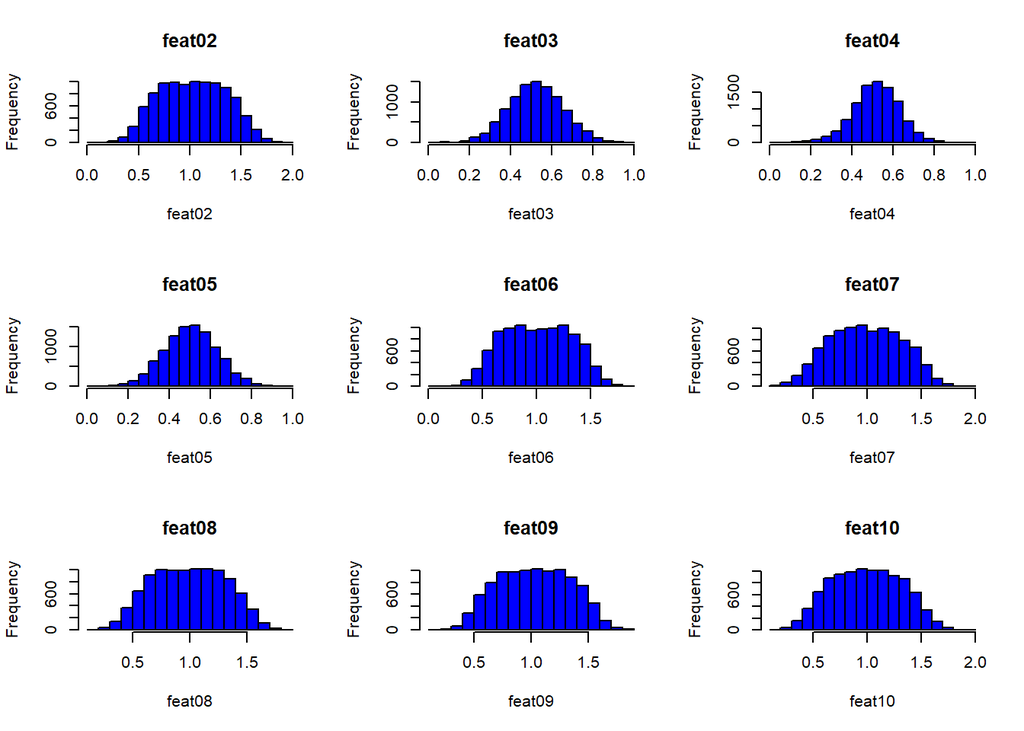

```r
hist(data$feat02, main = "feat02", xlab = "feat02", col = "blue")
hist(data$feat03, main = "feat03", xlab = "feat03", col = "blue")
hist(data$feat04, main = "feat04", xlab = "feat04", col = "blue")
hist(data$feat05, main = "feat05", xlab = "feat05", col = "blue")
hist(data$feat06, main = "feat06", xlab = "feat06", col = "blue")
hist(data$feat07, main = "feat07", xlab = "feat07", col = "blue")
hist(data$feat08, main = "feat08", xlab = "feat08", col = "blue")
hist(data$feat09, main = "feat09", xlab = "feat09", col = "blue")
hist(data$feat10, main = "feat10", xlab = "feat10", col = "blue")
```

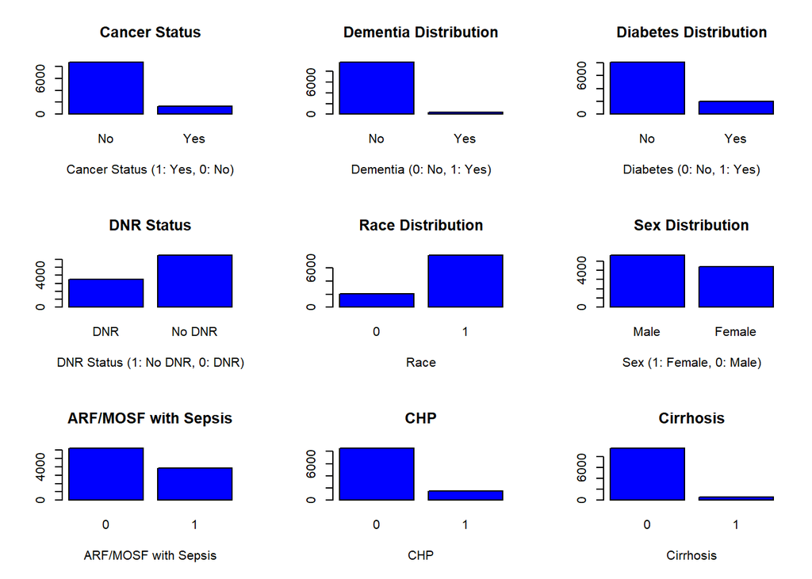

```r
par(mfrow = c(1, 1))


par(mfrow = c(3, 3))
# bar plots for categorical variables
barplot(table(data$ca), main = "Cancer Status",
        xlab = "Cancer Status (1: Yes, 0: No)", col = "blue",
        names.arg = c("No", "Yes"))
barplot(table(data$dementia), main = "Dementia Distribution", xlab = "Dementia (0: No, 1: Yes)", col = "blue", names.arg = c("No", "Yes"))
barplot(table(data$diabetes), main = "Diabetes Distribution", xlab = "Diabetes (0: No, 1: Yes)", col = "blue", names.arg = c("No", "Yes"))
barplot(table(data$dnr), main = "DNR Status",
        xlab = "DNR Status (1: No DNR, 0: DNR)", col = "blue",
        names.arg = c("DNR", "No DNR"))
barplot(table(data$race_white), main = "Race Distribution", xlab = "Race", col = "blue")
barplot(table(data$sex), main = "Sex Distribution",
        xlab = "Sex (1: Female, 0: Male)", col = "blue",
        names.arg = c("Male", "Female"))
barplot(table(data$arf_w_sepsis), main = "ARF/MOSF with Sepsis",
        xlab = "ARF/MOSF with Sepsis", col = "blue")
barplot(table(data$chp), main = "CHP",
        xlab = "CHP", col = "blue")
barplot(table(data$cirrhosis), main = "Cirrhosis",
        xlab = "Cirrhosis", col = "blue")
```

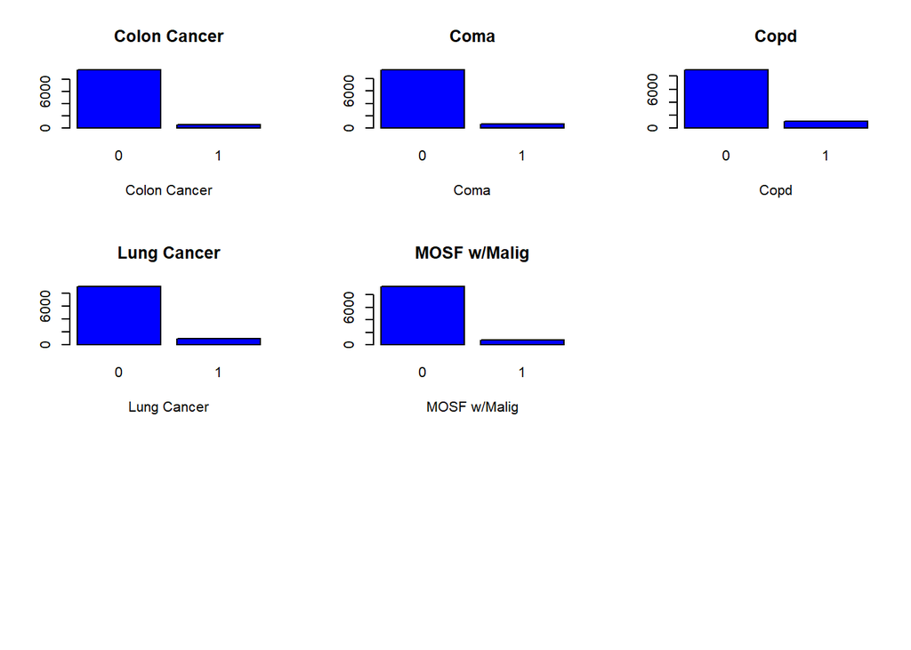

```r
barplot(table(data$colon_cancer), main = "Colon Cancer",
        xlab = "Colon Cancer", col = "blue")
barplot(table(data$coma), main = "Coma",
        xlab = "Coma", col = "blue")
barplot(table(data$copd), main = "Copd",
        xlab = "Copd", col = "blue")
barplot(table(data$lung_cancer), main = "Lung Cancer",
        xlab = "Lung Cancer", col = "blue")
barplot(table(data$mosf_w_malig), main = "MOSF w/Malig",
        xlab = "MOSF w/Malig", col = "blue")
par(mfrow = c(1, 1))
```

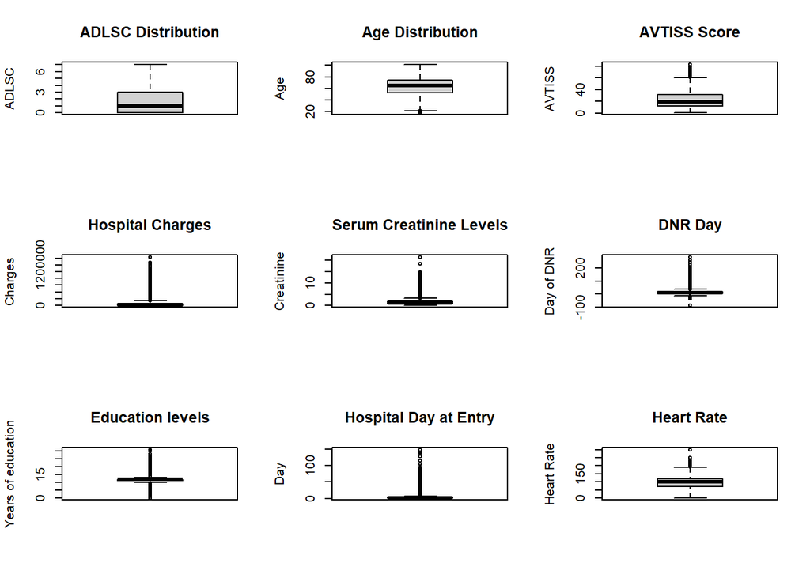

```r
# check for outliers
par(mfrow = c(3, 3))

# Boxplots for individual variables
boxplot(data$adlsc, main = "ADLSC Distribution", ylab = "ADLSC")
boxplot(data$age, main = "Age Distribution", ylab = "Age")
boxplot(data$avtisst, main = "AVTISS Score", ylab = "AVTISS")
boxplot(data$charges, main = "Hospital Charges", ylab = "Charges")
boxplot(data$crea, main = "Serum Creatinine Levels", ylab = "Creatinine")
boxplot(data$dnrday, main = "DNR Day", ylab = "Day of DNR")
boxplot(data$edu, main = "Education levels", ylab = "Years of education")
boxplot(data$hday, main = "Hospital Day at Entry", ylab = "Day")
boxplot(data$hrt, main = "Heart Rate", ylab = "Heart Rate")
```

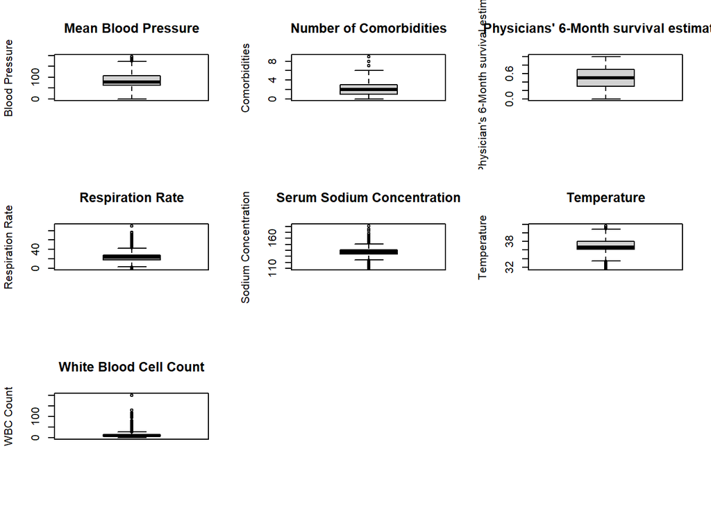

```r
boxplot(data$meanbp, main = "Mean Blood Pressure", ylab = "Blood Pressure")
boxplot(data$num.co, main = "Number of Comorbidities", ylab = "Comorbidities")
boxplot(data$prg6m, main = "Physicians' 6-Month survival estimates", ylab = "Physician's 6-Month survival estimate")
boxplot(data$resp, main = "Respiration Rate", ylab = "Respiration Rate")
boxplot(data$sod, main = "Serum Sodium Concentration", ylab = "Sodium Concentration")
boxplot(data$temp, main = "Temperature", ylab = "Temperature")
boxplot(data$wblc, main = "White Blood Cell Count", ylab = "WBC Count")
par(mfrow = c(1, 1))
```

## 2.Model selection

First, we divide data set into the training, validation and testing sample.

```r
set.seed(123456789)

# convert target variable from 0 and 1 to "No" and "Yes"
data$hospdead <- factor(data$hospdead, levels = c(0, 1), labels = c("No", "Yes"))

# Split data into training (70%) and initial testing (30%)
training_obs <- createDataPartition(data$hospdead, p = 0.7, list = FALSE)
data_train <- data[training_obs,]
data_test_initial <- data[-training_obs,]

# Further split the initial testing data into actual testing and validation sets (50% each of initial testing data)
testing_obs <- createDataPartition(data_test_initial$hospdead, p = 0.5, list = FALSE)
data_test <- data_test_initial[testing_obs,]
data_validation <- data_test_initial[-testing_obs,]
```

Examine frequencies of the target variable inside the training, validation and the testing set.

```r
table(data_train$hospdead)/length(data_train$hospdead)
```

```
##
##        No       Yes
## 0.7431219 0.2568781
```

```r
table(data_test$hospdead)/length(data_test$hospdead)
```

```
##
##        No       Yes
## 0.7431803 0.2568197
```

```r
table(data_validation$hospdead)/length(data_validation$hospdead)
```

```
##
##        No       Yes
## 0.7431803 0.2568197
```

### 2.1. Decision trees

```r
# First, we define formula of the model
model_1 <- hospdead ~ adlsc + age + avtisst + ca + charges + crea +
  dementia + diabetes + dnr + dnrday + edu + feat01 + feat02 + feat03 +
  feat04 + feat05 + feat06 + feat07 + feat08 + feat09 + feat10 + hday +
  hrt + meanbp + num.co + prg6m + resp + sex + sfdm2 + sod + temp + wblc +
  arf_w_sepsis + chp + cirrhosis + colon_cancer + coma +copd + lung_cancer +
  mosf_w_malig + race_white

# Next, we create the tree on the basis of all predictors.
tree_1 <-
  rpart(model_1,
        data = data_train,
        method = "class")
tree_1
```

```
## n= 7015
##
## node), split, n, loss, yval, (yprob)
##       * denotes terminal node
##
##  1) root 7015 1802 No (0.74312188 0.25687812)
##    2) sfdm2< 4.5 3608   50 No (0.98614191 0.01385809) *
##    3) sfdm2>=4.5 3407 1655 Yes (0.48576460 0.51423540)
##      6) avtisst< 27.875 1889  489 No (0.74113287 0.25886713)
##       12) dnr>=0.5 1059   66 No (0.93767705 0.06232295) *
##       13) dnr< 0.5 830  407 Yes (0.49036145 0.50963855)
##         26) avtisst< 18.83333 518  208 No (0.59845560 0.40154440)
##           52) feat03< 0.5595904 321   94 No (0.70716511 0.29283489) *
##           53) feat03>=0.5595904 197   83 Yes (0.42131980 0.57868020) *
##         27) avtisst>=18.83333 312   97 Yes (0.31089744 0.68910256) *
##      7) avtisst>=27.875 1518  255 Yes (0.16798419 0.83201581)
##       14) dnr>=0.5 455  191 Yes (0.41978022 0.58021978)
##         28) dnrday>=10.5 278  107 No (0.61510791 0.38489209)
##           56) avtisst< 41.54166 200   54 No (0.73000000 0.27000000) *
##           57) avtisst>=41.54166 78   25 Yes (0.32051282 0.67948718) *
##         29) dnrday< 10.5 177   20 Yes (0.11299435 0.88700565) *
##       15) dnr< 0.5 1063   64 Yes (0.06020696 0.93979304) *
```

[figure not shown]

```r
fancyRpartPlot(tree_1)
```

```r
summary(tree_1)
```

```
## Call:
## rpart(formula = model_1, data = data_train, method = "class")
##   n= 7015
##
##           CP nsplit rel error    xerror       xstd
## 1 0.27968923      0 1.0000000 1.0000000 0.02030732
## 2 0.03274140      2 0.4406215 0.4528302 0.01490175
## 3 0.01775805      4 0.3751387 0.3867925 0.01390393
## 4 0.01720311      6 0.3396226 0.3779134 0.01376081
## 5 0.01553829      7 0.3224195 0.3618202 0.01349541
## 6 0.01000000      8 0.3068812 0.3362930 0.01305758
##
## Variable importance
##        sfdm2      avtisst          dnr        prg6m       dnrday      charges
##           21           20           17            8            7            7
##        adlsc         hday arf_w_sepsis       meanbp          age       feat03
##            6            5            4            2            1            1
##         coma
##            1
##
## Node number 1: 7015 observations,    complexity param=0.2796892
##   predicted class=No   expected loss=0.2568781  P(node) =1
##     class counts:  5213  1802
##    probabilities: 0.743 0.257
##   left son=2 (3608 obs) right son=3 (3407 obs)
##   Primary splits:
##       sfdm2   < 4.5       to the left,  improve=877.4779, (0 missing)
##       dnr     < 0.5       to the right, improve=857.1905, (0 missing)
##       avtisst < 29.875    to the left,  improve=764.1820, (0 missing)
##       prg6m   < 0.265     to the right, improve=310.6363, (0 missing)
##       feat04  < 0.3559936 to the right, improve=193.0277, (0 missing)
##   Surrogate splits:
##       dnr     < 0.5       to the right, agree=0.703, adj=0.389, (0 split)
##       prg6m   < 0.4996199 to the right, agree=0.655, adj=0.289, (0 split)
##       avtisst < 28.70833  to the left,  agree=0.637, adj=0.252, (0 split)
##       adlsc   < 2.000244  to the left,  agree=0.630, adj=0.239, (0 split)
##       dnrday  < 5.5       to the right, agree=0.581, adj=0.137, (0 split)
##
## Node number 2: 3608 observations
##   predicted class=No   expected loss=0.01385809  P(node) =0.5143264
```

[output cut: 153 more lines]

```
##
## Node number 53: 197 observations
##   predicted class=Yes  expected loss=0.4213198  P(node) =0.02808268
##     class counts:    83   114
##    probabilities: 0.421 0.579
##
## Node number 56: 200 observations
##   predicted class=No   expected loss=0.27  P(node) =0.02851033
##     class counts:   146    54
##    probabilities: 0.730 0.270
##
## Node number 57: 78 observations
##   predicted class=Yes  expected loss=0.3205128  P(node) =0.01111903
##     class counts:    25    53
##    probabilities: 0.321 0.679
```

Now, we will try to do some alternative splits.

```r
tree_2 <-
  rpart(model_1,
        data = data_train,
        method = "class",
        parms = list(split = 'information'))

tree_2
```

```
## n= 7015
##
## node), split, n, loss, yval, (yprob)
##       * denotes terminal node
##
##  1) root 7015 1802 No (0.74312188 0.25687812)
##    2) sfdm2< 3.5 3580   45 No (0.98743017 0.01256983) *
##    3) sfdm2>=3.5 3435 1678 Yes (0.48850073 0.51149927)
##      6) avtisst< 28.875 1953  520 No (0.73374296 0.26625704)
##       12) dnr>=0.5 1096   78 No (0.92883212 0.07116788) *
##       13) dnr< 0.5 857  415 Yes (0.48424737 0.51575263)
##         26) avtisst< 18.83333 518  208 No (0.59845560 0.40154440) *
##         27) avtisst>=18.83333 339  105 Yes (0.30973451 0.69026549) *
##      7) avtisst>=28.875 1482  245 Yes (0.16531714 0.83468286)
##       14) dnr>=0.5 438  185 Yes (0.42237443 0.57762557)
##         28) dnrday>=10.5 267  102 No (0.61797753 0.38202247)
##           56) avtisst< 41.54166 185   49 No (0.73513514 0.26486486) *
##           57) avtisst>=41.54166 82   29 Yes (0.35365854 0.64634146) *
##         29) dnrday< 10.5 171   20 Yes (0.11695906 0.88304094) *
##       15) dnr< 0.5 1044   60 Yes (0.05747126 0.94252874) *
```

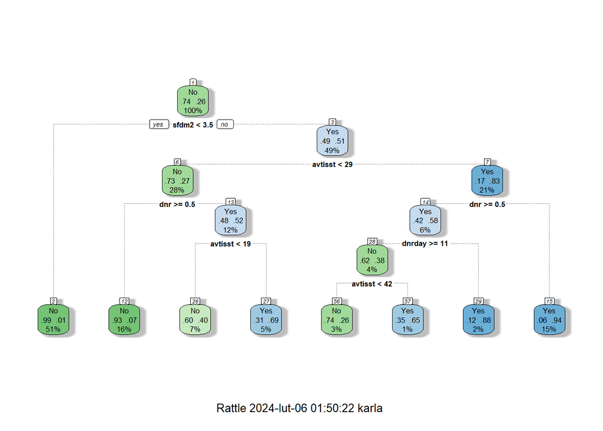

```r
fancyRpartPlot(tree_2)
```

```r
summary(tree_2)
```

```
## Call:
## rpart(formula = model_1, data = data_train, method = "class",
##     parms = list(split = "information"))
##   n= 7015
##
##           CP nsplit rel error    xerror       xstd
## 1 0.27524972      0 1.0000000 1.0000000 0.02030732
## 2 0.03579356      2 0.4495006 0.4611543 0.01501989
## 3 0.01748058      4 0.3779134 0.3940067 0.01401855
## 4 0.01331853      6 0.3429523 0.3518313 0.01332663
## 5 0.01000000      7 0.3296337 0.3446171 0.01320272
##
## Variable importance
##        sfdm2      avtisst          dnr        prg6m       dnrday        adlsc
##           25           18           18            9            7            7
##      charges         hday arf_w_sepsis       meanbp          age         coma
##            5            4            3            1            1            1
##
## Node number 1: 7015 observations,    complexity param=0.2752497
##   predicted class=No   expected loss=0.2568781  P(node) =1
##     class counts:  5213  1802
##    probabilities: 0.743 0.257
##   left son=2 (3580 obs) right son=3 (3435 obs)
##   Primary splits:
##       sfdm2   < 3.5       to the left,  improve=1375.2010, (0 missing)
##       dnr     < 0.5       to the right, improve=1119.0640, (0 missing)
##       avtisst < 28.875    to the left,  improve= 938.9291, (0 missing)
##       prg6m   < 0.265     to the right, improve= 370.6556, (0 missing)
##       charges < 15826.5   to the left,  improve= 256.0842, (0 missing)
##   Surrogate splits:
##       dnr     < 0.5       to the right, agree=0.701, adj=0.390, (0 split)
##       prg6m   < 0.4996199 to the right, agree=0.654, adj=0.294, (0 split)
##       avtisst < 28.70833  to the left,  agree=0.637, adj=0.260, (0 split)
##       adlsc   < 2.000244  to the left,  agree=0.631, adj=0.245, (0 split)
##       dnrday  < 5.5       to the right, agree=0.577, adj=0.137, (0 split)
##
## Node number 2: 3580 observations
##   predicted class=No   expected loss=0.01256983  P(node) =0.510335
##     class counts:  3535    45
##    probabilities: 0.987 0.013
```

[output cut: 128 more lines]

```
##
## Node number 29: 171 observations
##   predicted class=Yes  expected loss=0.1169591  P(node) =0.02437634
##     class counts:    20   151
##    probabilities: 0.117 0.883
##
## Node number 56: 185 observations
##   predicted class=No   expected loss=0.2648649  P(node) =0.02637206
##     class counts:   136    49
##    probabilities: 0.735 0.265
##
## Node number 57: 82 observations
##   predicted class=Yes  expected loss=0.3536585  P(node) =0.01168924
##     class counts:    29    53
##    probabilities: 0.354 0.646
```

In second tree ‘sfdm2’ taking the primary role in the decision process. This tree seems to have a more balanced distribution of splits, and ‘dnr’ and ‘avtisst’ also plays a significant role.

STOPPING CRITERIA

```r
tree_3 <-
  rpart(model_1,
        data = data_train,
        method = "class",
        minsplit = 700,
        minbucket = 70,
        maxdepth = 6)

tree_3
```

```
## n= 7015
##
## node), split, n, loss, yval, (yprob)
##       * denotes terminal node
##
##  1) root 7015 1802 No (0.74312188 0.25687812)
##    2) sfdm2< 4.5 3608   50 No (0.98614191 0.01385809) *
##    3) sfdm2>=4.5 3407 1655 Yes (0.48576460 0.51423540)
##      6) avtisst< 27.875 1889  489 No (0.74113287 0.25886713)
##       12) dnr>=0.5 1059   66 No (0.93767705 0.06232295) *
##       13) dnr< 0.5 830  407 Yes (0.49036145 0.50963855)
##         26) avtisst< 18.83333 518  208 No (0.59845560 0.40154440) *
##         27) avtisst>=18.83333 312   97 Yes (0.31089744 0.68910256) *
##      7) avtisst>=27.875 1518  255 Yes (0.16798419 0.83201581) *
```

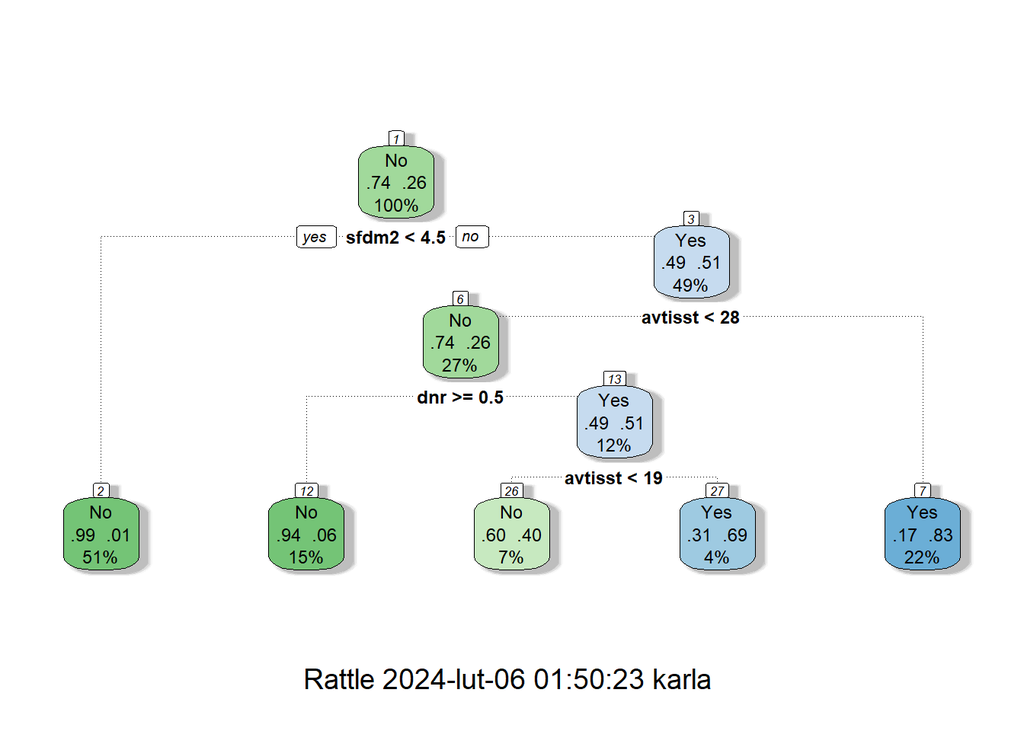

```r
fancyRpartPlot(tree_3)
```

```r
summary(tree_3)
```

```
## Call:
## rpart(formula = model_1, data = data_train, method = "class",
##     minsplit = 700, minbucket = 70, maxdepth = 6)
##   n= 7015
##
##          CP nsplit rel error    xerror       xstd
## 1 0.2796892      0 1.0000000 1.0000000 0.02030732
## 2 0.0327414      2 0.4406215 0.4511654 0.01487793
## 3 0.0100000      4 0.3751387 0.3984462 0.01408836
##
## Variable importance
##        sfdm2      avtisst          dnr        prg6m      charges        adlsc
##           23           21           16            8            7            6
##       dnrday         hday arf_w_sepsis       meanbp          age         coma
##            6            6            5            2            1            1
##
## Node number 1: 7015 observations,    complexity param=0.2796892
##   predicted class=No   expected loss=0.2568781  P(node) =1
##     class counts:  5213  1802
##    probabilities: 0.743 0.257
##   left son=2 (3608 obs) right son=3 (3407 obs)
##   Primary splits:
##       sfdm2   < 4.5       to the left,  improve=877.4779, (0 missing)
##       dnr     < 0.5       to the right, improve=857.1905, (0 missing)
##       avtisst < 29.875    to the left,  improve=764.1820, (0 missing)
##       prg6m   < 0.265     to the right, improve=310.6363, (0 missing)
##       feat04  < 0.3559936 to the right, improve=193.0277, (0 missing)
##   Surrogate splits:
##       dnr     < 0.5       to the right, agree=0.703, adj=0.389, (0 split)
##       prg6m   < 0.4996199 to the right, agree=0.655, adj=0.289, (0 split)
##       avtisst < 28.70833  to the left,  agree=0.637, adj=0.252, (0 split)
##       adlsc   < 2.000244  to the left,  agree=0.630, adj=0.239, (0 split)
##       dnrday  < 5.5       to the right, agree=0.581, adj=0.137, (0 split)
##
## Node number 2: 3608 observations
##   predicted class=No   expected loss=0.01385809  P(node) =0.5143264
##     class counts:  3558    50
##    probabilities: 0.986 0.014
##
## Node number 3: 3407 observations,    complexity param=0.2796892
```

[output cut: 57 more lines]

```
##       charges      < 26961.5   to the left,  agree=0.705, adj=0.215, (0 split)
##       hday         < 1.5       to the left,  agree=0.699, adj=0.199, (0 split)
##       arf_w_sepsis < 0.5       to the left,  agree=0.669, adj=0.119, (0 split)
##       dnrday       < 12.5      to the left,  agree=0.667, adj=0.115, (0 split)
##       mosf_w_malig < 0.5       to the left,  agree=0.652, adj=0.074, (0 split)
##
## Node number 26: 518 observations
##   predicted class=No   expected loss=0.4015444  P(node) =0.07384177
##     class counts:   310   208
##    probabilities: 0.598 0.402
##
## Node number 27: 312 observations
##   predicted class=Yes  expected loss=0.3108974  P(node) =0.04447612
##     class counts:    97   215
##    probabilities: 0.311 0.689
```

TREE COMPLEXITY

```r
tree_3a <-
  rpart(model_1,
        data = data_train,
        method = "class",
        minsplit = 700,
        minbucket = 70,
        maxdepth = 6,
        cp = -1)

tree_3a
```

```
## n= 7015
##
## node), split, n, loss, yval, (yprob)
##       * denotes terminal node
##
##  1) root 7015 1802 No (0.7431218817 0.2568781183)
##    2) sfdm2< 4.5 3608   50 No (0.9861419069 0.0138580931)
##      4) dnrday< 61.5 3439   10 No (0.9970921780 0.0029078220)
##        8) avtisst< 41.375 3356    4 No (0.9988081049 0.0011918951)
##         16) dnrday< 45.5 3263    1 No (0.9996935336 0.0003064664)
##           32) feat02< 1.636991 3193    0 No (1.0000000000 0.0000000000) *
##           33) feat02>=1.636991 70    1 No (0.9857142857 0.0142857143) *
##         17) dnrday>=45.5 93    3 No (0.9677419355 0.0322580645) *
##        9) avtisst>=41.375 83    6 No (0.9277108434 0.0722891566) *
##      5) dnrday>=61.5 169   40 No (0.7633136095 0.2366863905) *
##    3) sfdm2>=4.5 3407 1655 Yes (0.4857646023 0.5142353977)
##      6) avtisst< 27.875 1889  489 No (0.7411328745 0.2588671255)
##       12) dnr>=0.5 1059   66 No (0.9376770538 0.0623229462)
##         24) avtisst< 24.41666 968   46 No (0.9524793388 0.0475206612)
##           48) feat03< 0.6827822 872   30 No (0.9655963303 0.0344036697)
##             96) feat04>=0.4218369 758   19 No (0.9749340369 0.0250659631) *
##             97) feat04< 0.4218369 114   11 No (0.9035087719 0.0964912281) *
##           49) feat03>=0.6827822 96   16 No (0.8333333333 0.1666666667) *
##         25) avtisst>=24.41666 91   20 No (0.7802197802 0.2197802198) *
##       13) dnr< 0.5 830  407 Yes (0.4903614458 0.5096385542)
##         26) avtisst< 18.83333 518  208 No (0.5984555985 0.4015444015) *
##         27) avtisst>=18.83333 312   97 Yes (0.3108974359 0.6891025641) *
##      7) avtisst>=27.875 1518  255 Yes (0.1679841897 0.8320158103)
##       14) dnr>=0.5 455  191 Yes (0.4197802198 0.5802197802) *
##       15) dnr< 0.5 1063   64 Yes (0.0602069614 0.9397930386)
##         30) avtisst< 40.875 590   60 Yes (0.1016949153 0.8983050847) *
##         31) avtisst>=40.875 473    4 Yes (0.0084566596 0.9915433404) *
```

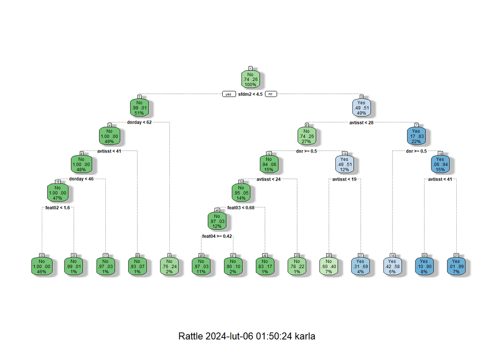

```r
fancyRpartPlot(tree_3a)
```

```r
summary(tree_3a)
```

```
## Call:
## rpart(formula = model_1, data = data_train, method = "class",
##     minsplit = 700, minbucket = 70, maxdepth = 6, cp = -1)
##   n= 7015
##
##           CP nsplit rel error    xerror       xstd
## 1  0.2796892      0 1.0000000 1.0000000 0.02030732
## 2  0.0327414      2 0.4406215 0.4450610 0.01479004
## 3  0.0000000      4 0.3751387 0.3984462 0.01408836
## 4 -1.0000000     13 0.3751387 0.3984462 0.01408836
##
## Variable importance
##        sfdm2      avtisst          dnr        prg6m      charges       dnrday
##           22           21           17            8            6            6
##        adlsc         hday arf_w_sepsis       meanbp          age         coma
##            6            5            4            2            1            1
##
## Node number 1: 7015 observations,    complexity param=0.2796892
##   predicted class=No   expected loss=0.2568781  P(node) =1
##     class counts:  5213  1802
##    probabilities: 0.743 0.257
##   left son=2 (3608 obs) right son=3 (3407 obs)
##   Primary splits:
##       sfdm2   < 4.5       to the left,  improve=877.4779, (0 missing)
##       dnr     < 0.5       to the right, improve=857.1905, (0 missing)
##       avtisst < 29.875    to the left,  improve=764.1820, (0 missing)
##       prg6m   < 0.265     to the right, improve=310.6363, (0 missing)
##       feat04  < 0.3559936 to the right, improve=193.0277, (0 missing)
##   Surrogate splits:
##       dnr     < 0.5       to the right, agree=0.703, adj=0.389, (0 split)
##       prg6m   < 0.4996199 to the right, agree=0.655, adj=0.289, (0 split)
##       avtisst < 28.70833  to the left,  agree=0.637, adj=0.252, (0 split)
##       adlsc   < 2.000244  to the left,  agree=0.630, adj=0.239, (0 split)
##       dnrday  < 5.5       to the right, agree=0.581, adj=0.137, (0 split)
##
## Node number 2: 3608 observations,    complexity param=0
##   predicted class=No   expected loss=0.01385809  P(node) =0.5143264
##     class counts:  3558    50
##    probabilities: 0.986 0.014
##
```

[output cut: 58 more lines]

```
##       charges      < 26961.5   to the left,  agree=0.705, adj=0.215, (0 split)
##       hday         < 1.5       to the left,  agree=0.699, adj=0.199, (0 split)
##       arf_w_sepsis < 0.5       to the left,  agree=0.669, adj=0.119, (0 split)
##       dnrday       < 12.5      to the left,  agree=0.667, adj=0.115, (0 split)
##       mosf_w_malig < 0.5       to the left,  agree=0.652, adj=0.074, (0 split)
##
## Node number 26: 518 observations
##   predicted class=No   expected loss=0.4015444  P(node) =0.07384177
##     class counts:   310   208
##    probabilities: 0.598 0.402
##
## Node number 27: 312 observations
##   predicted class=Yes  expected loss=0.3108974  P(node) =0.04447612
##     class counts:    97   215
##    probabilities: 0.311 0.689
```

We will compare the results of tree number 3.

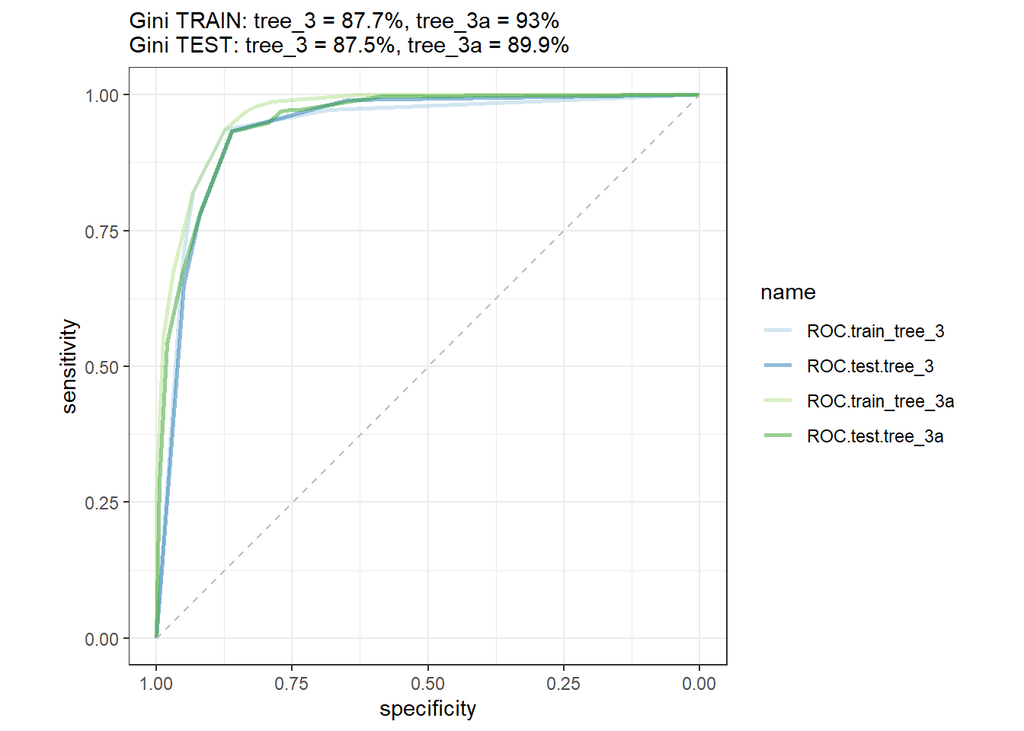

```r
# produce predictions on the training and testing sets
pred_train_tree_3 <- predict(tree_3, data_train)
pred_test_tree_3  <- predict(tree_3,  data_test)
pred_train_tree_3a <- predict(tree_3a, data_train)
pred_test_tree_3a  <- predict(tree_3a,  data_test)

# ROC curve
ROC.train_tree_3  <- roc(as.numeric(data_train$hospdead == "Yes"),
                        pred_train_tree_3[, 1])
ROC.test.tree_3  <- roc(as.numeric(data_test$hospdead == "Yes"),
                        pred_test_tree_3[, 1])
ROC.train_tree_3a  <- roc(as.numeric(data_train$hospdead == "Yes"),
                        pred_train_tree_3a[, 1])
ROC.test.tree_3a  <- roc(as.numeric(data_test$hospdead == "Yes"),
                        pred_test_tree_3a[, 1])
list(
  ROC.train_tree_3 = ROC.train_tree_3,
  ROC.test.tree_3 = ROC.test.tree_3,
  ROC.train_tree_3a = ROC.train_tree_3a,
  ROC.test.tree_3a = ROC.test.tree_3a
) %>%
  pROC::ggroc(alpha = 0.5, linetype = 1, size = 1) +
  geom_segment(aes(x = 1, xend = 0, y = 0, yend = 1),
               color = "grey",
               linetype = "dashed") +
  labs(subtitle = paste0("Gini TRAIN: ",
                         "tree_3 = ",
                         round(100*(2 * auc(ROC.train_tree_3) - 1), 1), "%, ",
                         "tree_3a = ",
                         round(100*(2 * auc(ROC.train_tree_3a) - 1), 1), "% ",
                         "\nGini TEST: ",
                         "tree_3 = ",
                         round(100*(2 * auc(ROC.test.tree_3) - 1), 1), "%, ",
                         "tree_3a = ",
                         round(100*(2 * auc(ROC.test.tree_3a) - 1), 1), "% "
                         )) +
  theme_bw() + coord_fixed() +
  scale_color_brewer(palette = "Paired")
```

PRUNING

```r
tree_4 <-
  rpart(model_1,
        data = data_train,
        method = "class",
        minsplit = 150,
        minbucket = 70,
        maxdepth = 10,
        cp = -1)

tree_4
```

```
## n= 7015
##
## node), split, n, loss, yval, (yprob)
##       * denotes terminal node
##
##   1) root 7015 1802 No (0.7431218817 0.2568781183)
##     2) sfdm2< 4.5 3608   50 No (0.9861419069 0.0138580931)
##       4) dnrday< 61.5 3439   10 No (0.9970921780 0.0029078220)
##         8) avtisst< 41.375 3356    4 No (0.9988081049 0.0011918951)
##          16) dnrday< 45.5 3263    1 No (0.9996935336 0.0003064664)
##            32) feat02< 1.636991 3193    0 No (1.0000000000 0.0000000000) *
##            33) feat02>=1.636991 70    1 No (0.9857142857 0.0142857143) *
##          17) dnrday>=45.5 93    3 No (0.9677419355 0.0322580645) *
##         9) avtisst>=41.375 83    6 No (0.9277108434 0.0722891566) *
##       5) dnrday>=61.5 169   40 No (0.7633136095 0.2366863905)
##        10) charges< 214773.3 71    6 No (0.9154929577 0.0845070423) *
##        11) charges>=214773.3 98   34 No (0.6530612245 0.3469387755) *
##     3) sfdm2>=4.5 3407 1655 Yes (0.4857646023 0.5142353977)
##       6) avtisst< 27.875 1889  489 No (0.7411328745 0.2588671255)
##        12) dnr>=0.5 1059   66 No (0.9376770538 0.0623229462)
##          24) avtisst< 24.41666 968   46 No (0.9524793388 0.0475206612)
##            48) feat03< 0.6827822 872   30 No (0.9655963303 0.0344036697)
##              96) feat04>=0.4218369 758   19 No (0.9749340369 0.0250659631)
##               192) age< 68.77597 487    4 No (0.9917864476 0.0082135524)
##                 384) adlsc< 3.268799 417    1 No (0.9976019185 0.0023980815)
##                   768) age>=41.90548 347    0 No (1.0000000000 0.0000000000) *
##                   769) age< 41.90548 70    1 No (0.9857142857 0.0142857143) *
##                 385) adlsc>=3.268799 70    3 No (0.9571428571 0.0428571429) *
##               193) age>=68.77597 271   15 No (0.9446494465 0.0553505535)
##                 386) feat05>=0.4342267 201    5 No (0.9751243781 0.0248756219)
##                   772) feat06< 1.021645 118    0 No (1.0000000000 0.0000000000) *
##                   773) feat06>=1.021645 83    5 No (0.9397590361 0.0602409639) *
##                 387) feat05< 0.4342267 70   10 No (0.8571428571 0.1428571429) *
##              97) feat04< 0.4218369 114   11 No (0.9035087719 0.0964912281) *
##            49) feat03>=0.6827822 96   16 No (0.8333333333 0.1666666667) *
##          25) avtisst>=24.41666 91   20 No (0.7802197802 0.2197802198) *
##        13) dnr< 0.5 830  407 Yes (0.4903614458 0.5096385542)
##          26) avtisst< 18.83333 518  208 No (0.5984555985 0.4015444015)
##            52) feat03< 0.5595904 321   94 No (0.7071651090 0.2928348910)
##             104) feat05>=0.4129238 249   59 No (0.7630522088 0.2369477912)
```

[output cut: 27 more lines]

```
##             122) crea< 2.049805 361   36 Yes (0.0997229917 0.9002770083)
##               244) feat05>=0.3733235 254   34 Yes (0.1338582677 0.8661417323)
##                 488) feat04>=0.4557956 160   29 Yes (0.1812500000 0.8187500000)
##                   976) crea>=1.049927 85   21 Yes (0.2470588235 0.7529411765) *
##                   977) crea< 1.049927 75    8 Yes (0.1066666667 0.8933333333) *
##                 489) feat04< 0.4557956 94    5 Yes (0.0531914894 0.9468085106) *
##               245) feat05< 0.3733235 107    2 Yes (0.0186915888 0.9813084112) *
##             123) crea>=2.049805 152    4 Yes (0.0263157895 0.9736842105)
##               246) feat10>=1.132533 70    4 Yes (0.0571428571 0.9428571429) *
##               247) feat10< 1.132533 82    0 Yes (0.0000000000 1.0000000000) *
##          31) avtisst>=40.875 473    4 Yes (0.0084566596 0.9915433404)
##            62) wblc>=20.99805 70    3 Yes (0.0428571429 0.9571428571) *
##            63) wblc< 20.99805 403    1 Yes (0.0024813896 0.9975186104)
##             126) charges< 31264 70    1 Yes (0.0142857143 0.9857142857) *
##             127) charges>=31264 333    0 Yes (0.0000000000 1.0000000000) *
```

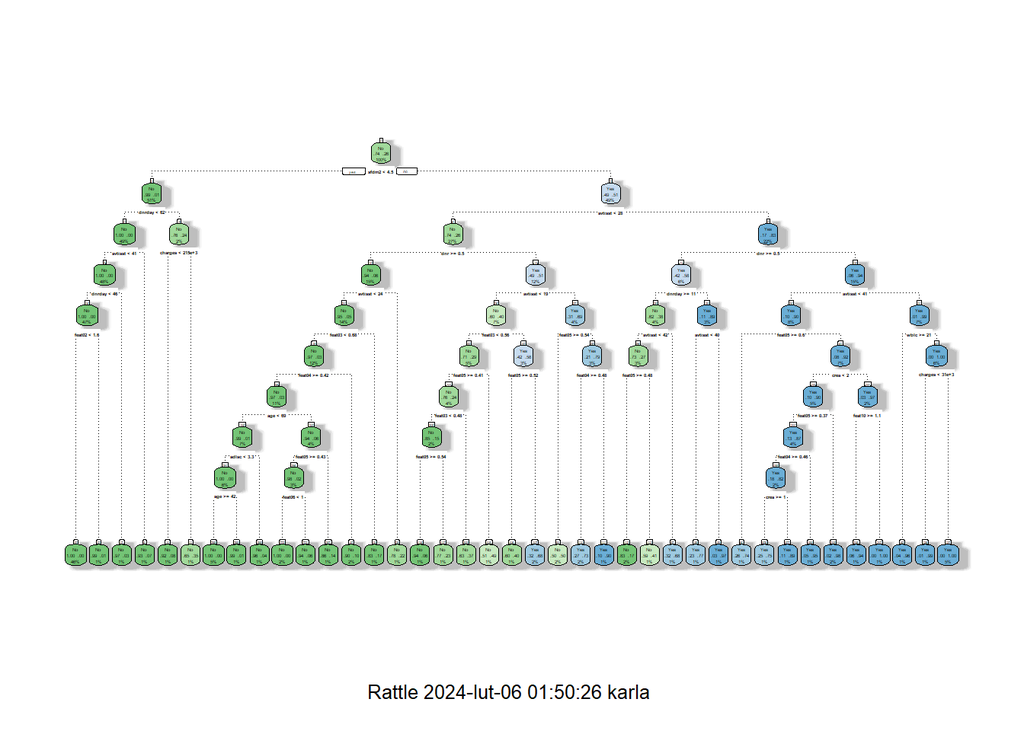

```r
fancyRpartPlot(tree_4)
```

```r
summary(tree_4)
```

```
## Call:
## rpart(formula = model_1, data = data_train, method = "class",
##     minsplit = 150, minbucket = 70, maxdepth = 10, cp = -1)
##   n= 7015
##
##             CP nsplit rel error    xerror       xstd
## 1  0.279689234      0 1.0000000 1.0000000 0.02030732
## 2  0.032741398      2 0.4406215 0.4445061 0.01478200
## 3  0.017758047      4 0.3751387 0.3834628 0.01385053
## 4  0.017203108      6 0.3396226 0.3779134 0.01376081
## 5  0.015538291      7 0.3224195 0.3568257 0.01341142
## 6  0.007769145      8 0.3068812 0.3213097 0.01279024
## 7  0.000554939      9 0.2991121 0.3318535 0.01297920
## 8  0.000000000     10 0.2985572 0.3285239 0.01291996
## 9 -1.000000000     38 0.2985572 0.3285239 0.01291996
##
## Variable importance
##        sfdm2      avtisst          dnr        prg6m       dnrday      charges
##           21           20           16            8            7            7
##        adlsc         hday arf_w_sepsis       meanbp       feat05       feat03
##            6            5            4            2            1            1
##          age         coma
##            1            1
##
## Node number 1: 7015 observations,    complexity param=0.2796892
##   predicted class=No   expected loss=0.2568781  P(node) =1
##     class counts:  5213  1802
##    probabilities: 0.743 0.257
##   left son=2 (3608 obs) right son=3 (3407 obs)
##   Primary splits:
##       sfdm2   < 4.5       to the left,  improve=877.4779, (0 missing)
##       dnr     < 0.5       to the right, improve=857.1905, (0 missing)
##       avtisst < 29.875    to the left,  improve=764.1820, (0 missing)
##       prg6m   < 0.265     to the right, improve=310.6363, (0 missing)
##       feat04  < 0.3559936 to the right, improve=193.0277, (0 missing)
##   Surrogate splits:
##       dnr     < 0.5       to the right, agree=0.703, adj=0.389, (0 split)
##       prg6m   < 0.4996199 to the right, agree=0.655, adj=0.289, (0 split)
##       avtisst < 28.70833  to the left,  agree=0.637, adj=0.252, (0 split)
##       adlsc   < 2.000244  to the left,  agree=0.630, adj=0.239, (0 split)
```

[output cut: 203 more lines]

```
##
## Node number 57: 78 observations
##   predicted class=Yes  expected loss=0.3205128  P(node) =0.01111903
##     class counts:    25    53
##    probabilities: 0.321 0.679
##
## Node number 106: 70 observations
##   predicted class=No   expected loss=0.4  P(node) =0.009978617
##     class counts:    42    28
##    probabilities: 0.600 0.400
##
## Node number 107: 127 observations
##   predicted class=Yes  expected loss=0.3228346  P(node) =0.01810406
##     class counts:    41    86
##    probabilities: 0.323 0.677
```

Now we will use it in prediction on training set.

```r
pred_tree_4 <- predict(tree_4, data_train, type = "class")
head(pred_tree_4)
```

```
##   1   2   4   5   7   8
## Yes  No Yes  No  No  No
## Levels: No Yes
```

```r
# Analyzing the fit the model to the training set.
confusionMatrix(data = pred_tree_4,
                reference = as.factor(data_train$hospdead),
                positive = "Yes")
```

```
## Confusion Matrix and Statistics
##
##           Reference
## Prediction   No  Yes
##        No  5021  346
##        Yes  192 1456
##
##                Accuracy : 0.9233
##                  95% CI : (0.9168, 0.9294)
##     No Information Rate : 0.7431
##     P-Value [Acc > NIR] : < 2.2e-16
##
##                   Kappa : 0.7933
##
##  Mcnemar's Test P-Value : 4.216e-11
##
##             Sensitivity : 0.8080
##             Specificity : 0.9632
##          Pos Pred Value : 0.8835
##          Neg Pred Value : 0.9355
##              Prevalence : 0.2569
##          Detection Rate : 0.2076
##    Detection Prevalence : 0.2349
##       Balanced Accuracy : 0.8856
##
##        'Positive' Class : Yes
##
```

The next step will be pruning the tree.

```r
printcp(tree_4)
```

```
##
## Classification tree:
## rpart(formula = model_1, data = data_train, method = "class",
##     minsplit = 150, minbucket = 70, maxdepth = 10, cp = -1)
##
## Variables actually used in tree construction:
##  [1] adlsc   age     avtisst charges crea    dnr     dnrday  feat02  feat03
## [10] feat04  feat05  feat06  feat10  sfdm2   wblc
##
## Root node error: 1802/7015 = 0.25688
##
## n= 7015
##
##            CP nsplit rel error  xerror     xstd
## 1  0.27968923      0   1.00000 1.00000 0.020307
## 2  0.03274140      2   0.44062 0.44451 0.014782
## 3  0.01775805      4   0.37514 0.38346 0.013851
## 4  0.01720311      6   0.33962 0.37791 0.013761
## 5  0.01553829      7   0.32242 0.35683 0.013411
## 6  0.00776915      8   0.30688 0.32131 0.012790
## 7  0.00055494      9   0.29911 0.33185 0.012979
## 8  0.00000000     10   0.29856 0.32852 0.012920
## 9 -1.00000000     38   0.29856 0.32852 0.012920
```

```r
# Find the number of cp row with lowest error
opt <- which.min(tree_4$cptable[, "xerror"])
opt
```

```
## 6
## 6
```

```r
# value of cp
cp <- tree_4$cptable[opt, "CP"]
cp
```

```
## [1] 0.007769145
```

```r
# using cp in process of tree pruning
tree_4p <-
  prune(tree_4, cp = cp)

tree_4p
```

```
## n= 7015
##
## node), split, n, loss, yval, (yprob)
##       * denotes terminal node
##
##  1) root 7015 1802 No (0.74312188 0.25687812)
##    2) sfdm2< 4.5 3608   50 No (0.98614191 0.01385809) *
##    3) sfdm2>=4.5 3407 1655 Yes (0.48576460 0.51423540)
##      6) avtisst< 27.875 1889  489 No (0.74113287 0.25886713)
##       12) dnr>=0.5 1059   66 No (0.93767705 0.06232295) *
##       13) dnr< 0.5 830  407 Yes (0.49036145 0.50963855)
##         26) avtisst< 18.83333 518  208 No (0.59845560 0.40154440)
##           52) feat03< 0.5595904 321   94 No (0.70716511 0.29283489) *
##           53) feat03>=0.5595904 197   83 Yes (0.42131980 0.57868020) *
##         27) avtisst>=18.83333 312   97 Yes (0.31089744 0.68910256) *
##      7) avtisst>=27.875 1518  255 Yes (0.16798419 0.83201581)
##       14) dnr>=0.5 455  191 Yes (0.41978022 0.58021978)
##         28) dnrday>=10.5 278  107 No (0.61510791 0.38489209)
##           56) avtisst< 41.54166 200   54 No (0.73000000 0.27000000) *
##           57) avtisst>=41.54166 78   25 Yes (0.32051282 0.67948718) *
##         29) dnrday< 10.5 177   20 Yes (0.11299435 0.88700565) *
##       15) dnr< 0.5 1063   64 Yes (0.06020696 0.93979304) *
```

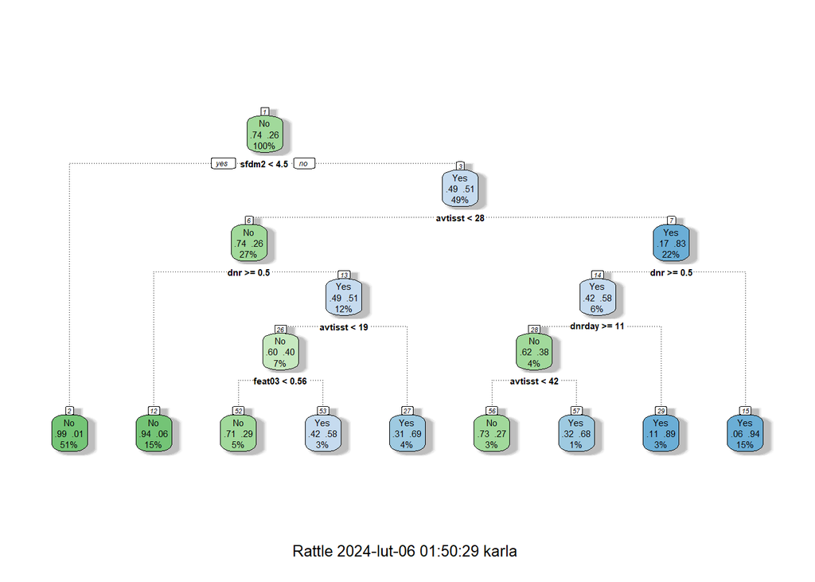

```r
fancyRpartPlot(tree_4p)
```

```r
summary(tree_4p)
```

```
## Call:
## rpart(formula = model_1, data = data_train, method = "class",
##     minsplit = 150, minbucket = 70, maxdepth = 10, cp = -1)
##   n= 7015
##
##            CP nsplit rel error    xerror       xstd
## 1 0.279689234      0 1.0000000 1.0000000 0.02030732
## 2 0.032741398      2 0.4406215 0.4445061 0.01478200
## 3 0.017758047      4 0.3751387 0.3834628 0.01385053
## 4 0.017203108      6 0.3396226 0.3779134 0.01376081
## 5 0.015538291      7 0.3224195 0.3568257 0.01341142
## 6 0.007769145      8 0.3068812 0.3213097 0.01279024
##
## Variable importance
##        sfdm2      avtisst          dnr        prg6m       dnrday      charges
##           21           20           17            8            7            7
##        adlsc         hday arf_w_sepsis       meanbp          age       feat03
##            6            5            4            2            1            1
##         coma
##            1
##
## Node number 1: 7015 observations,    complexity param=0.2796892
##   predicted class=No   expected loss=0.2568781  P(node) =1
##     class counts:  5213  1802
##    probabilities: 0.743 0.257
##   left son=2 (3608 obs) right son=3 (3407 obs)
##   Primary splits:
##       sfdm2   < 4.5       to the left,  improve=877.4779, (0 missing)
##       dnr     < 0.5       to the right, improve=857.1905, (0 missing)
##       avtisst < 29.875    to the left,  improve=764.1820, (0 missing)
##       prg6m   < 0.265     to the right, improve=310.6363, (0 missing)
##       feat04  < 0.3559936 to the right, improve=193.0277, (0 missing)
##   Surrogate splits:
##       dnr     < 0.5       to the right, agree=0.703, adj=0.389, (0 split)
##       prg6m   < 0.4996199 to the right, agree=0.655, adj=0.289, (0 split)
##       avtisst < 28.70833  to the left,  agree=0.637, adj=0.252, (0 split)
##       adlsc   < 2.000244  to the left,  agree=0.630, adj=0.239, (0 split)
##       dnrday  < 5.5       to the right, agree=0.581, adj=0.137, (0 split)
##
## Node number 2: 3608 observations
```

[output cut: 154 more lines]

```
##
## Node number 53: 197 observations
##   predicted class=Yes  expected loss=0.4213198  P(node) =0.02808268
##     class counts:    83   114
##    probabilities: 0.421 0.579
##
## Node number 56: 200 observations
##   predicted class=No   expected loss=0.27  P(node) =0.02851033
##     class counts:   146    54
##    probabilities: 0.730 0.270
##
## Node number 57: 78 observations
##   predicted class=Yes  expected loss=0.3205128  P(node) =0.01111903
##     class counts:    25    53
##    probabilities: 0.321 0.679
```

This is the most complex tree.

We will compare the results of tree number 4.

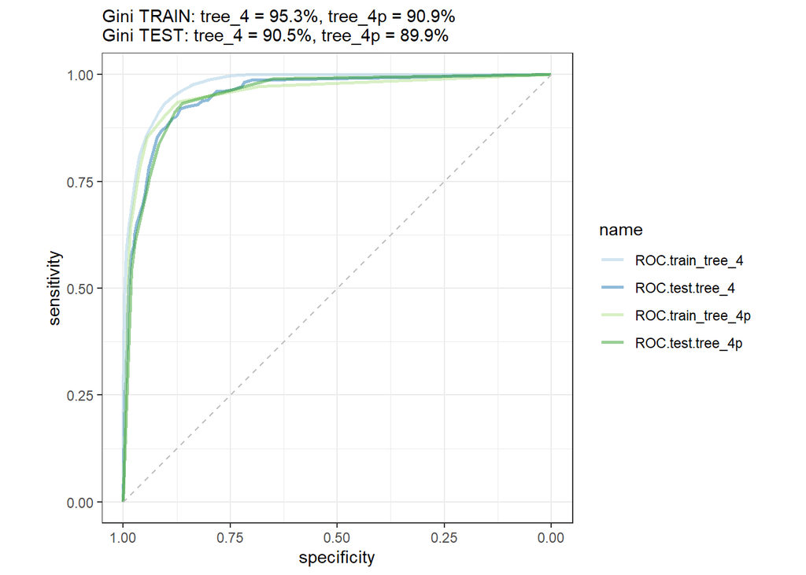

```r
# produce predictions on the training and testing sets
pred_train_tree_4 <- predict(tree_4, data_train)
pred_test_tree_4  <- predict(tree_4,  data_test)
pred_train_tree_4p <- predict(tree_4p, data_train)
pred_test_tree_4p  <- predict(tree_4p,  data_test)

# ROC curve
ROC.train_tree_4  <- roc(as.numeric(data_train$hospdead == "Yes"),
                        pred_train_tree_4[, 1])
ROC.test.tree_4  <- roc(as.numeric(data_test$hospdead == "Yes"),
                        pred_test_tree_4[, 1])
ROC.train_tree_4p  <- roc(as.numeric(data_train$hospdead == "Yes"),
                        pred_train_tree_4p[, 1])
ROC.test.tree_4p  <- roc(as.numeric(data_test$hospdead == "Yes"),
                        pred_test_tree_4p[, 1])
list(
  ROC.train_tree_4 = ROC.train_tree_4,
  ROC.test.tree_4 = ROC.test.tree_4,
  ROC.train_tree_4p = ROC.train_tree_4p,
  ROC.test.tree_4p = ROC.test.tree_4p
) %>%
  pROC::ggroc(alpha = 0.5, linetype = 1, size = 1) +
  geom_segment(aes(x = 1, xend = 0, y = 0, yend = 1),
               color = "grey",
               linetype = "dashed") +
  labs(subtitle = paste0("Gini TRAIN: ",
                         "tree_4 = ",
                         round(100*(2 * auc(ROC.train_tree_4) - 1), 1), "%, ",
                         "tree_4p = ",
                         round(100*(2 * auc(ROC.train_tree_4p) - 1), 1), "% ",
                         "\nGini TEST: ",
                         "tree_4 = ",
                         round(100*(2 * auc(ROC.test.tree_4) - 1), 1), "%, ",
                         "tree_4p = ",
                         round(100*(2 * auc(ROC.test.tree_4p) - 1), 1), "% "
                         )) +
  theme_bw() + coord_fixed() +
  scale_color_brewer(palette = "Paired")
```

So tree_4 performs a little bit better (Gini train = 95.3%) than tree after pruning. Testing and training sets perform similarly.

Last step is to estimate the tree with the caret package.

```r
tc <- trainControl(method = "cv",
                   number = 10,
                   classProbs = TRUE,
                   summaryFunction = twoClassSummary)
modelLookup("rpart")
```

```
##   model parameter                label forReg forClass probModel
## 1 rpart        cp Complexity Parameter   TRUE     TRUE      TRUE
```

```r
cp.grid <- expand.grid(cp = seq(0, 0.03, 0.001))
set.seed(123456789)

tree_5 <-
  train(model_1,
        data = data_train,
        method = "rpart",
        metric = "ROC",
        trControl = tc,
        tuneGrid  = cp.grid)

tree_5
```

```
## CART
##
## 7015 samples
##   41 predictor
##    2 classes: 'No', 'Yes'
##
## No pre-processing
## Resampling: Cross-Validated (10 fold)
## Summary of sample sizes: 6314, 6312, 6312, 6314, 6314, 6314, ...
## Resampling results across tuning parameters:
##
##   cp     ROC        Sens       Spec
##   0.000  0.9557968  0.9388040  0.8307397
##   0.001  0.9589198  0.9424464  0.8424033
##   0.002  0.9609931  0.9499305  0.8390638
##   0.003  0.9618519  0.9512730  0.8324095
##   0.004  0.9615307  0.9468599  0.8313045
##   0.005  0.9604410  0.9447496  0.8362983
##   0.006  0.9548969  0.9453251  0.8318570
##   0.007  0.9525855  0.9435984  0.8351964
##   0.008  0.9525019  0.9432149  0.8346347
##   0.009  0.9464828  0.9437896  0.8296624
##   0.010  0.9465505  0.9443654  0.8252179
##   0.011  0.9464614  0.9462848  0.8185513
##   0.012  0.9464202  0.9466679  0.8152363
##   0.013  0.9446302  0.9474353  0.8085758
##   0.014  0.9429774  0.9445617  0.8119091
##   0.015  0.9418058  0.9428332  0.8091314
##   0.016  0.9417237  0.9430251  0.8052425
##   0.017  0.9377612  0.9391864  0.7985758
##   0.018  0.9361063  0.9399541  0.7902425
##   0.019  0.9335722  0.9317114  0.8057428
##   0.020  0.9316364  0.9272954  0.8174217
##   0.021  0.9315909  0.9324678  0.8080295
##   0.022  0.9315674  0.9347710  0.8035850
##   0.023  0.9315674  0.9347710  0.8035850
##   0.024  0.9315674  0.9347710  0.8035850
##   0.025  0.9315674  0.9347710  0.8035850
##   0.026  0.9315674  0.9347710  0.8035850
##   0.027  0.9315674  0.9347710  0.8035850
##   0.028  0.9315674  0.9347710  0.8035850
##   0.029  0.9315674  0.9347710  0.8035850
##   0.030  0.9315674  0.9347710  0.8035850
##
## ROC was used to select the optimal model using the largest value.
## The final value used for the model was cp = 0.003.
```

At the end we will compare all the results.

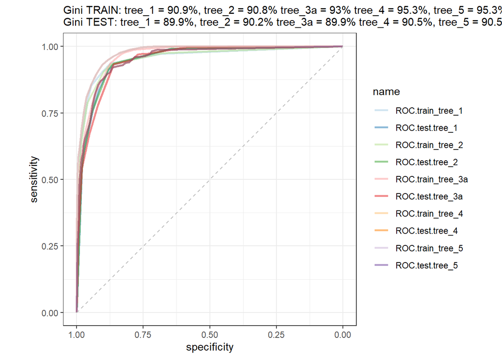

```r
# produce predictions on the training and testing sets
pred_train_tree_1  <- predict(tree_1,  data_train)
pred_test_tree_1  <- predict(tree_1,  data_test)
pred_train_tree_2 <- predict(tree_2, data_train)
pred_test_tree_2  <- predict(tree_2,  data_test)
pred_train_tree_3a <- predict(tree_3a, data_train)
pred_test_tree_3a  <- predict(tree_3a,  data_test)
pred_train_tree_4 <- predict(tree_4, data_train)
pred_test_tree_4  <- predict(tree_4,  data_test)
pred_train_tree_5 <- predict(tree_5, data_train)
pred_test_tree_5  <- predict(tree_5,  data_test)

# ROC curve
ROC.train_tree_1  <- roc(as.numeric(data_train$hospdead == "Yes"),
                        pred_train_tree_1[, 1])
ROC.test.tree_1  <- roc(as.numeric(data_test$hospdead == "Yes"),
                        pred_test_tree_1[, 1])
ROC.train_tree_2  <- roc(as.numeric(data_train$hospdead == "Yes"),
                        pred_train_tree_2[, 1])
ROC.test.tree_2  <- roc(as.numeric(data_test$hospdead == "Yes"),
                        pred_test_tree_2[, 1])
ROC.train_tree_3a  <- roc(as.numeric(data_train$hospdead == "Yes"),
                        pred_train_tree_3a[, 1])
ROC.test.tree_3a  <- roc(as.numeric(data_test$hospdead == "Yes"),
                        pred_test_tree_3a[, 1])
ROC.train_tree_4  <- roc(as.numeric(data_train$hospdead == "Yes"),
                        pred_train_tree_4[, 1])
ROC.test.tree_4  <- roc(as.numeric(data_test$hospdead == "Yes"),
                        pred_test_tree_4[, 1])
ROC.train_tree_5  <- roc(as.numeric(data_train$hospdead == "Yes"),
                        pred_train_tree_4[, 1])
ROC.test.tree_5  <- roc(as.numeric(data_test$hospdead == "Yes"),
                        pred_test_tree_4[, 1])
list(
  ROC.train_tree_1  = ROC.train_tree_1,
  ROC.test.tree_1 = ROC.test.tree_1,
  ROC.train_tree_2 = ROC.train_tree_2,
  ROC.test.tree_2 = ROC.test.tree_2,
  ROC.train_tree_3a = ROC.train_tree_3a,
  ROC.test.tree_3a = ROC.test.tree_3a,
  ROC.train_tree_4 = ROC.train_tree_4,
  ROC.test.tree_4 = ROC.test.tree_4,
  ROC.train_tree_5 = ROC.train_tree_5,
  ROC.test.tree_5 = ROC.test.tree_5
) %>%
  pROC::ggroc(alpha = 0.5, linetype = 1, size = 1) +
  geom_segment(aes(x = 1, xend = 0, y = 0, yend = 1),
               color = "grey",
               linetype = "dashed") +
  labs(subtitle = paste0("Gini TRAIN: ",
                         "tree_1 = ",
                         round(100*(2 * auc(ROC.train_tree_1) - 1), 1), "%, ",
                         "tree_2 = ",
                         round(100*(2 * auc(ROC.train_tree_2) - 1), 1), "% ",
                         "tree_3a = ",
                         round(100*(2 * auc(ROC.train_tree_3a) - 1), 1), "% ",
                         "tree_4 = ",
                         round(100*(2 * auc(ROC.train_tree_4) - 1), 1), "%, ",
                         "tree_5 = ",
                         round(100*(2 * auc(ROC.train_tree_5) - 1), 1), "%, ",
                         "\nGini TEST: ",
                         "tree_1 = ",
                         round(100*(2 * auc(ROC.test.tree_1) - 1), 1), "%, ",
                         "tree_2 = ",
                         round(100*(2 * auc(ROC.test.tree_2) - 1), 1), "% ",
                         "tree_3a = ",
                         round(100*(2 * auc(ROC.test.tree_3a) - 1), 1), "% ",
                         "tree_4 = ",
                         round(100*(2 * auc(ROC.test.tree_4) - 1), 1), "%, ",
                         "tree_5 = ",
                         round(100*(2 * auc(ROC.test.tree_5) - 1), 1), "%, "
                         )) +
  theme_bw() +
  coord_fixed() +
  scale_color_brewer(palette = "Paired") +
  theme(
    legend.position = "right"
  )
```

Final version of the model.

```r
dt_final <- tree_5$finalModel
```

Importance of predictors.

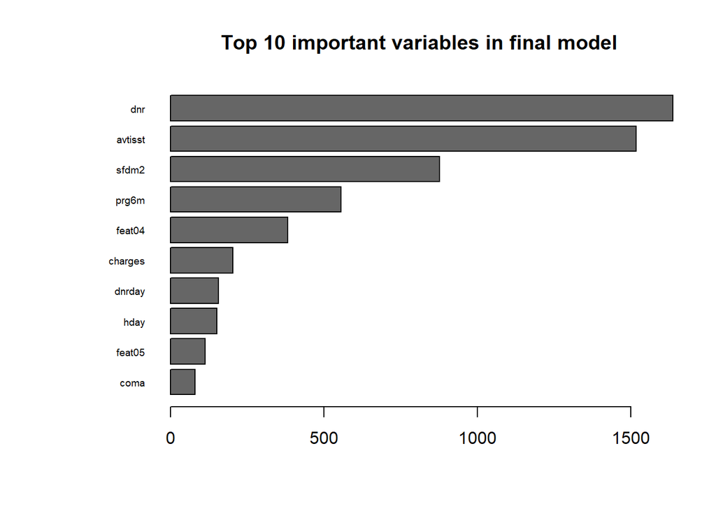

```r
dt_final.importance <- varImp(dt_final) %>%
  as.data.frame() %>%
  rownames_to_column("variable") %>%
  arrange(desc(Overall)) %>%
  top_n(10, Overall)

par(mar = c(5, 8, 4, 2) + 0.1)

barplot(
  rev(dt_final.importance$Overall),
  names.arg = rev(dt_final.importance$variable),
  col = "grey40",
  main = "Top 10 important variables in final model",
  horiz = TRUE,
  las = 1,
  cex.names = 0.6
)
```

dnr appears to be the most important predictor The next two important variables are avtisst and sfdm2 prg6m, feat04, charges, dnrday, hday, feat05, coma also seem to be important

### 2.2 Random Forests

```r
# running random forest function
rf1 <- randomForest(model_1, data = data_train)
print(rf1)
```

```
##
## Call:
##  randomForest(formula = model_1, data = data_train)
##                Type of random forest: classification
##                      Number of trees: 500
## No. of variables tried at each split: 6
##
##         OOB estimate of  error rate: 6.66%
## Confusion matrix:
##       No  Yes class.error
## No  5027  186  0.03568003
## Yes  281 1521  0.15593785
```

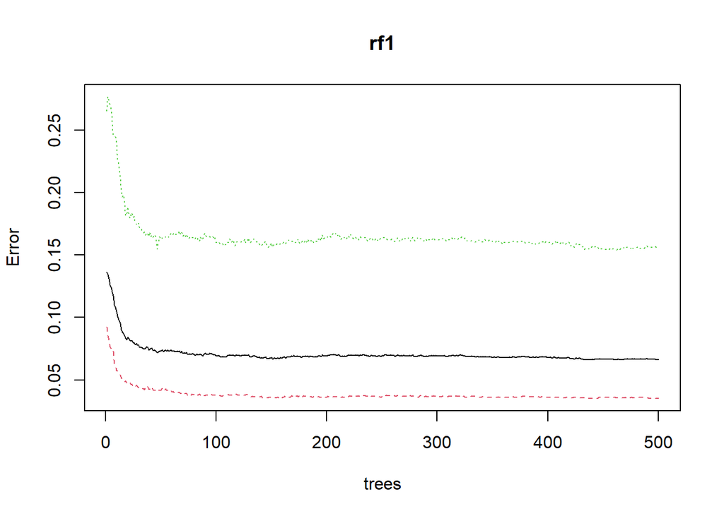

```r
plot(rf1)
```

A total of 500 trees were constructed. At each split in the construction of the trees, 6 predictor variables were tried. The out-of-bag (OOB) estimate of error rate is 6.66%, which is the estimated prediction error on the training data.

Class error is lower for predictions of “no” value and higher for “Yes”.

Trying to limit number of trees and estimate the model on bootstrap samples from the full data set. Also increasing and trying different numbers of predictors.

```r
rf2 <-
  randomForest(model_1,
               data = data_train,
               ntree = 50,
               sampsize = nrow(data_train),
               mtry = 12,
               # minimum number of obs in the terminal nodes
               nodesize = 50,
               # we also generate predictors importance measures,
               importance = TRUE)
print(rf2)
```

```
##
## Call:
##  randomForest(formula = model_1, data = data_train, ntree = 50,      sampsize = nrow(data_train), mtry = 12, nodesize = 50, importance = TRUE)
##                Type of random forest: classification
##                      Number of trees: 50
## No. of variables tried at each split: 12
##
##         OOB estimate of  error rate: 7.37%
## Confusion matrix:
##       No  Yes class.error
## No  4965  248  0.04757337
## Yes  269 1533  0.14927858
```

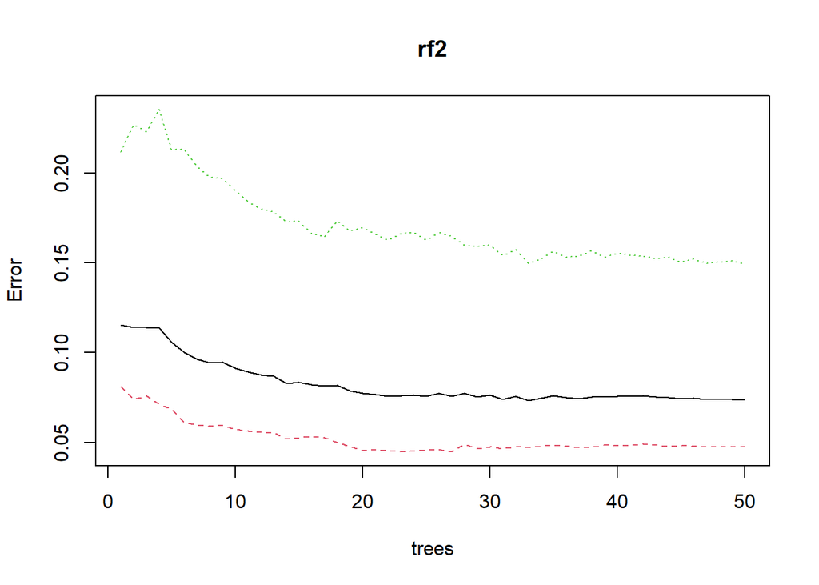

```r
plot(rf2)
```

The OOB error is a little bit higher now.

```r
parameters_rf <- expand.grid(mtry = 2:40)
ctrl_oob <- trainControl(method = "oob", classProbs = TRUE)

train.rf3 <-
    train(model_1,
          data = data_train,
          method = "rf",
          ntree = 50,
          nodesize = 50,
          tuneGrid = parameters_rf,
          trControl = ctrl_oob,
          importance = TRUE)

train.rf3
```

```
## Random Forest
##
## 7015 samples
##   41 predictor
##    2 classes: 'No', 'Yes'
##
## No pre-processing
## Resampling results across tuning parameters:
##
##   mtry  Accuracy   Kappa
##    2    0.9034925  0.7270503
##    3    0.9138988  0.7652712
##    4    0.9204562  0.7843703
##    5    0.9213115  0.7876466
##    6    0.9225944  0.7958816
```

[output cut: 37 more lines]

```r
str(train.rf3)
```

[output not shown]

[output cut: 238 more lines]

[output not shown]

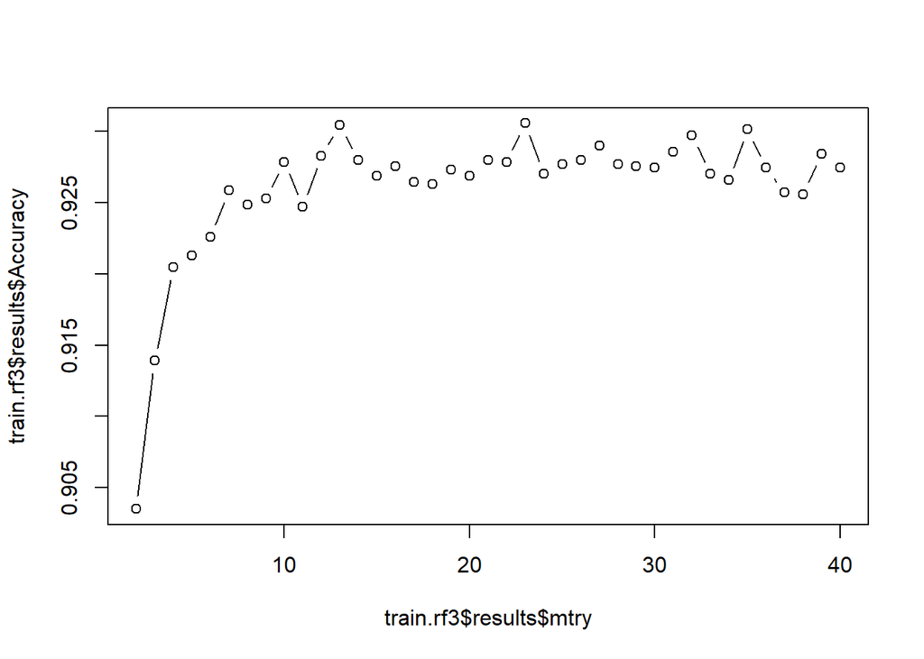

```r
plot(train.rf3$results$mtry,
     train.rf3$results$Accuracy, type = "b")
```

Based on outputs the optimal value of mtry should be 23.

```r
rf3<-
  randomForest(model_1,
               data = data_train,
               ntree = 50,
               sampsize = nrow(data_train),
               mtry = 23,
               nodesize = 50,
               importance = TRUE)
str(rf3)
```

[output not shown]

[output cut: 52 more lines]

[output not shown]

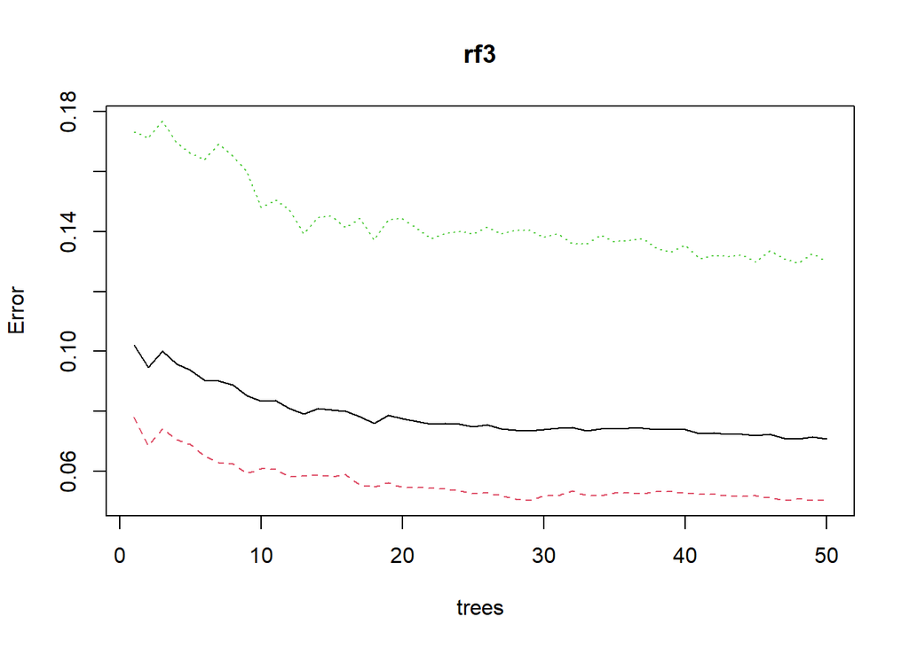

```r
plot(rf3)
```

Comparing all the models on the ROC curves.

```r
pred.train.rf1 <- predict(rf1, data_train, type = "prob")[, "Yes"]
pred.test.rf1  <- predict(rf1, data_test, type = "prob")[, "Yes"]
pred.train.rf2 <- predict(rf2, data_train, type = "prob")[, "Yes"]
pred.test.rf2  <- predict(rf2, data_test, type = "prob")[, "Yes"]
pred.train.rf3 <- predict(rf3, data_train, type = "prob")[, "Yes"]
pred.test.rf3  <- predict(rf3, data_test, type = "prob")[, "Yes"]

ROC.train.rf1  <- roc(as.numeric(data_train$hospdead == "Yes"),
                     pred.train.rf1)
ROC.test.rf1   <- roc(as.numeric(data_test$hospdead == "Yes"),
                     pred.test.rf1)
ROC.train.rf2  <- roc(as.numeric(data_train$hospdead == "Yes"),
                      pred.train.rf2)
ROC.test.rf2   <- roc(as.numeric(data_test$hospdead == "Yes"),
                      pred.test.rf2)
ROC.train.rf3  <- roc(as.numeric(data_train$hospdead == "Yes"),
                      pred.train.rf3)
ROC.test.rf3   <- roc(as.numeric(data_test$hospdead == "Yes"),
                      pred.test.rf3)
```

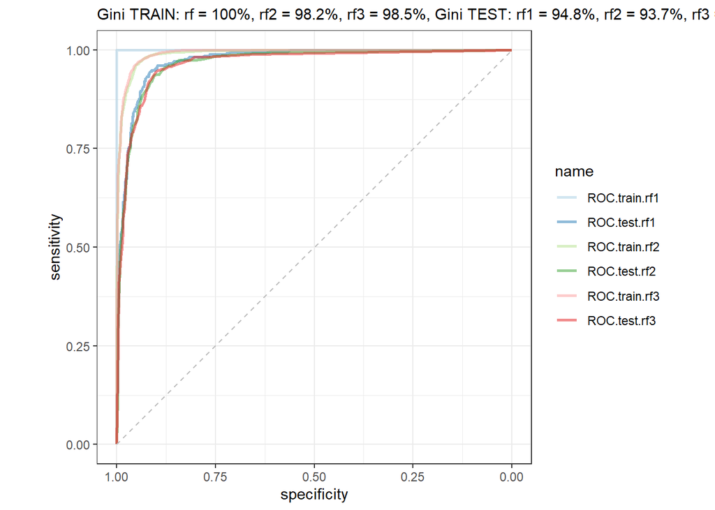

```r
list(
  ROC.train.rf1 = ROC.train.rf1,
  ROC.test.rf1 = ROC.test.rf1,
  ROC.train.rf2 = ROC.train.rf2,
  ROC.test.rf2 = ROC.test.rf2,
  ROC.train.rf3 = ROC.train.rf3,
  ROC.test.rf3 = ROC.test.rf3
) %>%
  pROC::ggroc(alpha = 0.5, linetype = 1, size = 1) +
  geom_segment(aes(x = 1, xend = 0, y = 0, yend = 1),
               color = "grey",
               linetype = "dashed") +
  labs(subtitle = paste0("Gini TRAIN: ",
                          "rf = ",
                          round(100 * (2 * auc(ROC.train.rf1) - 1), 1), "%, ",
                          "rf2 = ",
                          round(100 * (2 * auc(ROC.train.rf2) - 1), 1), "%, ",
                          "rf3 = ",
                          round(100 * (2 * auc(ROC.train.rf3) - 1), 1), "%, ",
                         "Gini TEST: ",
                         "rf1 = ",
                         round(100 * (2 * auc(ROC.test.rf1) - 1), 1), "%, ",
                         "rf2 = ",
                         round(100 * (2 * auc(ROC.test.rf2) - 1), 1), "%, ",
                         "rf3 = ",
                         round(100 * (2 * auc(ROC.test.rf3) - 1), 1), "%, ")) +
  theme_bw() + coord_fixed() +
  scale_color_brewer(palette = "Paired")
```

For rf1 the Gini coefficient is 100% on the training set, which probably indicates overfitting. The rf2 has a larger gini test compared to the rf3 but in turn the rf3 has a slightly higher gini train.

Calculating accuracy, sensitivity, specificity and the Gini coefficient.

```r
getAccuracyAndGini(model = rf2, data = data_train,
                   target_variable = "hospdead",
                   predicted_class = "Yes")
```

```
##    Accuracy Sensitivity Specificity        Gini
##   0.9542409   0.9078801   0.9702666   0.9821904
```

```r
getAccuracyAndGini(model = rf2, data = data_test,
                   target_variable = "hospdead",
                   predicted_class = "Yes")
```

```
##    Accuracy Sensitivity Specificity        Gini
##   0.9214904   0.8601036   0.9427037   0.9367175
```

```r
getAccuracyAndGini(model = rf3, data = data_train,
                   target_variable = "hospdead",
                   predicted_class = "Yes")
```

```
##    Accuracy Sensitivity Specificity        Gini
##   0.9583749   0.9317425   0.9675810   0.9846021
```

```r
getAccuracyAndGini(model = rf3, data = data_test,
                   target_variable = "hospdead",
                   predicted_class = "Yes")
```

```
##    Accuracy Sensitivity Specificity        Gini
##   0.9141717   0.8626943   0.9319606   0.9329463
```

Final version of the model.

```r
rf_final <- rf3
```

Importance of predictors.

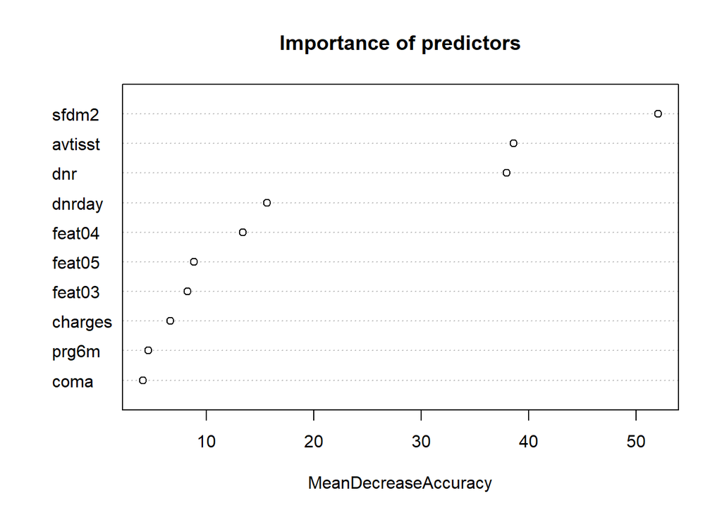

```r
varImpPlot(rf_final,
           sort = TRUE,
           main = "Importance of predictors",
           n.var = 10,
           type = 1)
```

sfdm2 appears to be the most important predictor The next two important variables are avtisst and dnr dnrday, feat04, feat05, feat03 and charges also seem to be important

### 2.3 Boosting of Decision Trees (XGBoost):

```r
parameters_xgb <- expand.grid(nrounds = seq(20, 80, 10),
                              max_depth = c(6),
                              eta = c(0.25),
                              gamma = 1,
                              colsample_bytree = c(0.2),
                              min_child_weight = c(100),
                              subsample = 0.8)

ctrl_cv3 <- trainControl(method = "cv",
                         number = 3,
                         classProbs = TRUE,
                         summaryFunction = twoClassSummary)

set.seed(123456789)
xgb <- train(model_1,
             data = data_train,
             method = "xgbTree",
             trControl = ctrl_cv3,
             tuneGrid  = parameters_xgb)
```

[output not shown]

```r
xgb
```

```
## eXtreme Gradient Boosting
##
## 7015 samples
##   41 predictor
##    2 classes: 'No', 'Yes'
##
## No pre-processing
## Resampling: Cross-Validated (3 fold)
## Summary of sample sizes: 4676, 4676, 4678
## Resampling results across tuning parameters:
##
##   nrounds  ROC        Sens       Spec
##   20       0.9679756  0.9650865  0.7480625
##   30       0.9681737  0.9639362  0.7674811
##   40       0.9693321  0.9616341  0.7791366
##   50       0.9695007  0.9600999  0.7885746
##   60       0.9696065  0.9600996  0.7952311
##   70       0.9693962  0.9577976  0.7968931
##   80       0.9694937  0.9577976  0.7985580
##
## Tuning parameter 'max_depth' was held constant at a value of 6
## Tuning
##  parameter 'min_child_weight' was held constant at a value of 100
##
## Tuning parameter 'subsample' was held constant at a value of 0.8
## ROC was used to select the optimal model using the largest value.
## The final values used for the model were nrounds = 60, max_depth = 6, eta
##  = 0.25, gamma = 1, colsample_bytree = 0.2, min_child_weight = 100
##  and subsample = 0.8.
```

The best result has been obtained for nrounds = 60

```r
parameters_xgb2 <- expand.grid(nrounds = 60,
                              max_depth = seq(5, 15, 2),
                              eta = c(0.25),
                              gamma = 1,
                              colsample_bytree = c(0.2),
                              min_child_weight = seq(50, 100, 50),
                              subsample = 0.8)

set.seed(123456789)
xgb2 <- train(model_1,
              data = data_train,
              method = "xgbTree",
              trControl = ctrl_cv3,
              tuneGrid  = parameters_xgb2)
xgb2
```

```
## eXtreme Gradient Boosting
##
## 7015 samples
##   41 predictor
##    2 classes: 'No', 'Yes'
##
## No pre-processing
## Resampling: Cross-Validated (3 fold)
## Summary of sample sizes: 4676, 4676, 4678
## Resampling results across tuning parameters:
##
##   max_depth  min_child_weight  ROC        Sens       Spec
##    5          50               0.9730985  0.9593322  0.8251987
##    5         100               0.9703292  0.9591414  0.7985515
##    7          50               0.9742791  0.9585651  0.8296293
##    7         100               0.9713286  0.9581811  0.8074348
##    9          50               0.9736881  0.9577975  0.8196432
##    9         100               0.9697297  0.9612508  0.7968904
##   11          50               0.9741432  0.9610587  0.8340728
##   11         100               0.9698204  0.9593326  0.7946746
##   13          50               0.9748563  0.9589491  0.8296330
##   13         100               0.9698732  0.9583730  0.8029987
##   15          50               0.9744167  0.9604829  0.8257524
##   15         100               0.9689579  0.9579902  0.7952237
##
## Tuning parameter 'nrounds' was held constant at a value of 60
## Tuning
##  'colsample_bytree' was held constant at a value of 0.2
## Tuning
##  parameter 'subsample' was held constant at a value of 0.8
## ROC was used to select the optimal model using the largest value.
## The final values used for the model were nrounds = 60, max_depth = 13, eta
##  = 0.25, gamma = 1, colsample_bytree = 0.2, min_child_weight = 50 and
##  subsample = 0.8.
```

The best result has been obtained for maxdepth = 13 and min_child_weight = 50.

```r
parameters_xgb3 <- expand.grid(nrounds = 60,
                              max_depth = 13,
                              eta = c(0.25),
                              gamma = 1,
                              colsample_bytree = seq(0.1, 0.8, 0.1),
                              min_child_weight = 50,
                              subsample = 0.8)
set.seed(123456789)
xgb3 <- train(model_1,
                      data = data_train,
                      method = "xgbTree",
                      trControl = ctrl_cv3,
                      tuneGrid  = parameters_xgb3)
xgb3
```

```
## eXtreme Gradient Boosting
##
## 7015 samples
##   41 predictor
##    2 classes: 'No', 'Yes'
##
## No pre-processing
## Resampling: Cross-Validated (3 fold)
## Summary of sample sizes: 4676, 4676, 4678
## Resampling results across tuning parameters:
##
##   colsample_bytree  ROC        Sens       Spec
##   0.1               0.9717642  0.9554967  0.8068737
##   0.2               0.9741120  0.9560716  0.8296321
##   0.3               0.9742584  0.9583727  0.8301913
##   0.4               0.9744875  0.9589485  0.8346284
##   0.5               0.9742689  0.9574142  0.8351793
##   0.6               0.9743217  0.9568386  0.8340710
##   0.7               0.9742033  0.9560710  0.8351821
##   0.8               0.9737208  0.9562631  0.8329627
##
## Tuning parameter 'nrounds' was held constant at a value of 60
## Tuning
##  'min_child_weight' was held constant at a value of 50
## Tuning
##  parameter 'subsample' was held constant at a value of 0.8
## ROC was used to select the optimal model using the largest value.
## The final values used for the model were nrounds = 60, max_depth = 13, eta
##  = 0.25, gamma = 1, colsample_bytree = 0.4, min_child_weight = 50 and
##  subsample = 0.8.
```

The best result has been obtained for colsample_bytree = 0.4.

```r
parameters_xgb4 <- expand.grid(nrounds = 60,
                              max_depth = 13,
                              eta = c(0.25),
                              gamma = 1,
                              colsample_bytree = 0.4,
                              min_child_weight = 50,
                              subsample = c(0.5, 0.6, 0.7, 0.8, 0.9))

set.seed(123456789)
xgb4 <- train(model_1,
                      data = data_train,
                      method = "xgbTree",
                      trControl = ctrl_cv3,
                      tuneGrid  = parameters_xgb4)
xgb4
```

```
## eXtreme Gradient Boosting
##
## 7015 samples
##   41 predictor
##    2 classes: 'No', 'Yes'
##
## No pre-processing
## Resampling: Cross-Validated (3 fold)
## Summary of sample sizes: 4676, 4676, 4678
## Resampling results across tuning parameters:
##
##   subsample  ROC        Sens       Spec
##   0.5        0.9713752  0.9570301  0.8157635
##   0.6        0.9729084  0.9581811  0.8240839
##   0.7        0.9737759  0.9570300  0.8335182
##   0.8        0.9741363  0.9579889  0.8368451
##   0.9        0.9746660  0.9576057  0.8374025
##
## Tuning parameter 'nrounds' was held constant at a value of 60
## Tuning
##  'colsample_bytree' was held constant at a value of 0.4
## Tuning
##  parameter 'min_child_weight' was held constant at a value of 50
## ROC was used to select the optimal model using the largest value.
## The final values used for the model were nrounds = 60, max_depth = 13, eta
##  = 0.25, gamma = 1, colsample_bytree = 0.4, min_child_weight = 50 and
##  subsample = 0.9.
```

The best result has been obtained for subsample = 0.9.

Next is to lower learning rate by half (up to 0.12), and double the number of trees.

```r
parameters_xgb5 <- expand.grid(nrounds = 120,
                              max_depth = 13,
                              eta = 0.12,
                              gamma = 1,
                              colsample_bytree = 0.4,
                              min_child_weight = 50,
                              subsample = 0.9)

set.seed(123456789)
xgb5 <- train(model_1,
                      data = data_train,
                      method = "xgbTree",
                      trControl = ctrl_cv3,
                      tuneGrid  = parameters_xgb5)
xgb5
```

```
## eXtreme Gradient Boosting
##
## 7015 samples
##   41 predictor
##    2 classes: 'No', 'Yes'
##
## No pre-processing
## Resampling: Cross-Validated (3 fold)
## Summary of sample sizes: 4676, 4676, 4678
## Resampling results:
##
##   ROC        Sens       Spec
##   0.9753227  0.9572227  0.834071
##
## Tuning parameter 'nrounds' was held constant at a value of 120
## Tuning
##  parameter 'min_child_weight' was held constant at a value of 50
##
## Tuning parameter 'subsample' was held constant at a value of 0.9
```

Next is to lower learning rate by half (up to 0.06), and double the number of trees.

```r
parameters_xgb6 <- expand.grid(nrounds = 240,
                              max_depth = 13,
                              eta = 0.06,
                              gamma = 1,
                              colsample_bytree = 0.4,
                              min_child_weight = 50,
                              subsample = 0.9)

set.seed(123456789)
xgb6 <- train(model_1,
                      data = data_train,
                      method = "xgbTree",
                      trControl = ctrl_cv3,
                      tuneGrid  = parameters_xgb6)
xgb6
```

```
## eXtreme Gradient Boosting
##
## 7015 samples
##   41 predictor
##    2 classes: 'No', 'Yes'
##
## No pre-processing
## Resampling: Cross-Validated (3 fold)
## Summary of sample sizes: 4676, 4676, 4678
## Resampling results:
##
##   ROC       Sens      Spec
##   0.975547  0.958373  0.8368441
##
## Tuning parameter 'nrounds' was held constant at a value of 240
## Tuning
##  parameter 'min_child_weight' was held constant at a value of 50
##
## Tuning parameter 'subsample' was held constant at a value of 0.9
```

Now, we will compare estimated the models.

```r
(models <- c("", "2":"6"))
```

```
## [1] ""  "2" "3" "4" "5" "6"
```

```r
sapply(paste0("xgb", models),
       function(x) getAccuracyAndGini(model = get(x),
                                      data = data_train,
                                      target_variable = "hospdead",
                                      predicted_class = "Yes")
)
```

```
##                   xgb      xgb2      xgb3      xgb4      xgb5      xgb6
## Accuracy    0.9314326 0.9449751 0.9451176 0.9451176 0.9465431 0.9478261
## Sensitivity 0.8407325 0.8784684 0.8812431 0.8817980 0.8806881 0.8840178
## Specificity 0.9627853 0.9679647 0.9671974 0.9670056 0.9693075 0.9698830
## Gini        0.9579635 0.9694695 0.9696273 0.9716286 0.9724014 0.9727085
```

```r
sapply(paste0("xgb", models),
       function(x) getAccuracyAndGini(model = get(x),
                                      data = data_test,
                                      target_variable = "hospdead",
                                      predicted_class = "Yes")
)
```

```
##                   xgb      xgb2      xgb3      xgb4      xgb5      xgb6
## Accuracy    0.9135063 0.9194943 0.9214904 0.9188290 0.9261477 0.9228210
## Sensitivity 0.8290155 0.8419689 0.8678756 0.8471503 0.8730570 0.8626943
## Specificity 0.9427037 0.9462847 0.9400179 0.9435989 0.9444942 0.9435989
## Gini        0.9338810 0.9416693 0.9426434 0.9428614 0.9438123 0.9428567
```

```r
ROC.train.xgb <- pROC::roc(data_train$hospdead, predict(xgb, data_train,
                                                        type = "prob")[, "Yes"])
ROC.test.xgb <- pROC::roc(data_test$hospdead, predict(xgb, data_test,
                                                        type = "prob")[, "Yes"])
ROC.train.xgb5 <- pROC::roc(data_train$hospdead, predict(xgb5, data_train,
                                                        type = "prob")[, "Yes"])
ROC.test.xgb5 <- pROC::roc(data_test$hospdead, predict(xgb5, data_test,
                                                        type = "prob")[, "Yes"])
ROC.train.xgb6 <- pROC::roc(data_train$hospdead, predict(xgb6, data_train,
                                                        type = "prob")[, "Yes"])
ROC.test.xgb6 <- pROC::roc(data_test$hospdead, predict(xgb6, data_test,
                                                        type = "prob")[, "Yes"])
```

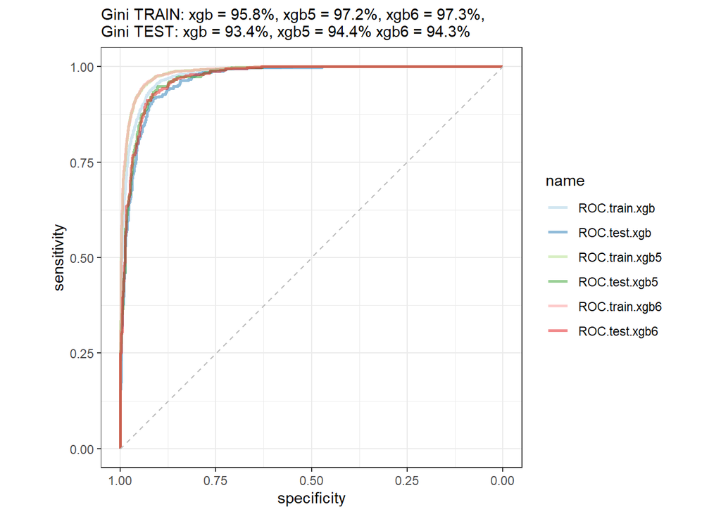

```r
list(
  ROC.train.xgb  = ROC.train.xgb,
  ROC.test.xgb   = ROC.test.xgb,
  ROC.train.xgb5  = ROC.train.xgb5,
  ROC.test.xgb5   = ROC.test.xgb5,
  ROC.train.xgb6 = ROC.train.xgb6,
  ROC.test.xgb6 = ROC.test.xgb6
) %>%
  pROC::ggroc(alpha = 0.5, linetype = 1, size = 1) +
  geom_segment(aes(x = 1, xend = 0, y = 0, yend = 1),
               color = "grey",
               linetype = "dashed") +
  labs(subtitle = paste0("Gini TRAIN: ",
                         "xgb = ",
                         round(100 * (2 * auc(ROC.train.xgb) - 1), 1), "%, ",
                         "xgb5 = ",
                         round(100 * (2 * auc(ROC.train.xgb5) - 1), 1), "%, ",
                         "xgb6 = ",
                         round(100 * (2 * auc(ROC.train.xgb6) - 1), 1), "%, ",
                         "\nGini TEST: ",
                         "xgb = ",
                         round(100 * (2 * auc(ROC.test.xgb) - 1), 1), "%, ",
                         "xgb5 = ",
                         round(100 * (2 * auc(ROC.test.xgb5) - 1), 1), "% ",
                         "xgb6 = ",
                         round(100 * (2 * auc(ROC.test.xgb6) - 1), 1), "% ")) +
  theme_bw() + coord_fixed() +
  scale_color_brewer(palette = "Paired")
```

The xgb6 model has a slightly higher Gini coefficient and other metrics especially on training datasets.

Importance of predictors.

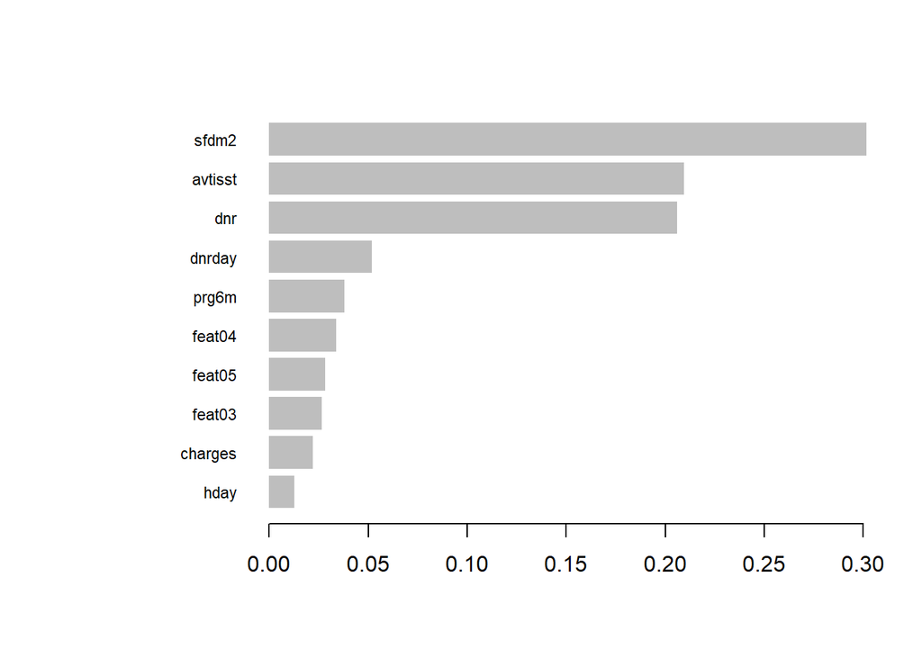

```r
xgb_final <- xgb6$finalModel

importance_matrix <- xgb.importance(
  feature_names = colnames(data_train[, -which(names(data_train) == "hospdead")]),
  model = xgb_final
)

top_n_importance_matrix <- importance_matrix[order(-importance_matrix$Gain), ][1:10,]

xgb.plot.importance(top_n_importance_matrix)
```

sfdm2 appears to be the most important predictor The next two important variables are dnr and avtisst dnrday, prg6m, feat04, feat05, feat03 and charges also seem to be important

## 3. Conclusions

For this problem we trained **three individual machine learning algorithms**: - Decision Tree (Gini train = 95.3%, Gini test = 90.5%), - Random Forest (Gini train = 98.5%, Gini test = 93.3%), - XGBoost (Gini train = 97.3%, Gini test = 94.3%).

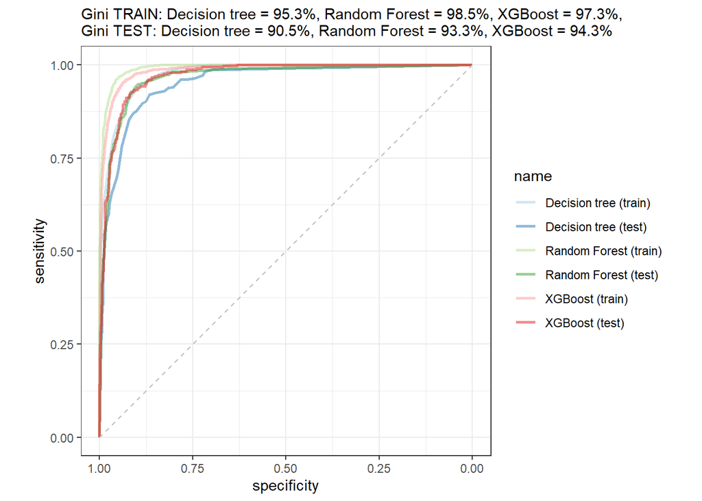

```r
list(
  'Decision tree (train)' = ROC.train_tree_5,
  'Decision tree (test)' = ROC.test.tree_5,
  'Random Forest (train)' = ROC.train.rf3,
  'Random Forest (test)' = ROC.test.rf3,
  'XGBoost (train)' = ROC.train.xgb6,
  'XGBoost (test)' = ROC.test.xgb6
) %>%
  pROC::ggroc(alpha = 0.5, linetype = 1, size = 1) +
  geom_segment(aes(x = 1, xend = 0, y = 0, yend = 1),
               color = "grey",
               linetype = "dashed") +
  labs(subtitle = paste0("Gini TRAIN: ",
                         "Decision tree = ",
                         round(100*(2 * auc(ROC.train_tree_5) - 1), 1), "%, ",
                          "Random Forest = ",
                          round(100 * (2 * auc(ROC.train.rf3) - 1), 1), "%, ",
                         "XGBoost = ",
                         round(100 * (2 * auc(ROC.train.xgb6) - 1), 1), "%, ",
                         "\nGini TEST: ",
                         "Decision tree = ",
                         round(100*(2 * auc(ROC.test.tree_5) - 1), 1), "%, " ,
                         "Random Forest = ",
                         round(100 * (2 * auc(ROC.test.rf3) - 1), 1), "%, ",
                         "XGBoost = ",
                         round(100 * (2 * auc(ROC.test.xgb6) - 1), 1), "% ")) +
  theme_bw() + coord_fixed() +
  scale_color_brewer(palette = "Paired")
```

Creating predictions on validation set

```r
predictions <- predict(rf_final, newdata = data_validation)

actuals <- data_validation$hospdead
comparison <- table(actuals, predictions)

# Calculate the proportion of correct predictions
accuracy <- sum(diag(comparison)) / sum(comparison)

print(accuracy)
```

```
## [1] 0.9234864
```

```r
print(comparison)
```

```
##        predictions
## actuals   No  Yes
##     No  1055   62
##     Yes   53  333
```

```r
# write.csv(predictions, file = "Predictions.csv", row.names = FALSE)
```

Copyright © 2023 [WNE UW](http://www.wne.uw.edu.pl). All rights reserved.